# German Bank Credit Homework

Alexander Liden & Samy Maurer

2023-06-06

# Introduction

# Exploring the Data

First of all lets call our data check for fundamentals such as :

```r
credit_data <- read.csv("GermanCredit.csv", sep = ";")
# Check number of rows and columns
n_rows <- nrow(credit_data)
n_cols <- ncol(credit_data)
cat("Number of rows: ", n_rows, "\n")
```

```
## Number of rows:  1000
```

```r
cat("Number of columns: ", n_cols, "\n\n")
```

```
## Number of columns:  32
```

```r
# Check data types of each column
str(credit_data)
```

```
## 'data.frame':    1000 obs. of  32 variables:
##  $ OBS.            : int  1 2 3 4 5 6 7 8 9 10 ...
##  $ CHK_ACCT        : int  0 1 3 0 0 3 3 1 3 1 ...
##  $ DURATION        : int  6 48 12 42 24 36 24 36 12 30 ...
##  $ HISTORY         : int  4 2 4 2 3 2 2 2 2 4 ...
##  $ NEW_CAR         : int  0 0 0 0 1 0 0 0 0 1 ...
##  $ USED_CAR        : int  0 0 0 0 0 0 0 1 0 0 ...
##  $ FURNITURE       : int  0 0 0 1 0 0 1 0 0 0 ...
##  $ RADIO.TV        : int  1 1 0 0 0 0 0 0 1 0 ...
##  $ EDUCATION       : int  0 0 1 0 0 1 0 0 0 0 ...
##  $ RETRAINING      : int  0 0 0 0 0 0 0 0 0 0 ...
##  $ AMOUNT          : int  1169 5951 2096 7882 4870 9055 2835 6948 3059 5234 ...
##  $ SAV_ACCT        : int  4 0 0 0 0 4 2 0 3 0 ...
##  $ EMPLOYMENT      : int  4 2 3 3 2 2 4 2 3 0 ...
##  $ INSTALL_RATE    : int  4 2 2 2 3 2 3 2 2 4 ...
```

[output cut: 18 more lines]

```r
cat("\n")
```

We observe that the data contains 1000 observations which are here obviously clients. For every client we have 32 integrere variables listed down below: `OBS#`, `CHK_ACCT`, `DURATION`, `HISTORY`, `NEW_CAR`, `USED_CAR`, `FURNITURE`, `RADIO/TV`, `EDUCATION`, `RETRAINING`, `AMOUNT`, `SAV_ACCT`, `EMPLOYMENT`, `INSTALL_RATE`, `MALE_DIV`, `MALE_SINGLE`, `MALE_MAR_WID`, `CO-APPLICANT`, `GUARANTOR`, `PRESENT_RESIDENT`, `REAL_ESTATE`, `PROP_UNKN_NONE`, `AGE`, `OTHER_INSTALL`, `RENT`, `OWN_RES`, `NUM_CREDITS`, `JOB`, `NUM_DEPENDENTS`, `TELEPHONE`, `FOREIGN`, `RESPONSE`

Lets check how many binary variable we have

```r
# create a function to identify binary variables
is_binary <- function(x) {
  if(is.numeric(x)) {
    if(all(x %in% c(0, 1))) {
      return(TRUE)
    }
  }
  return(FALSE)
}

# apply the function to each column in your dataframe
binary_vars <- sapply(credit_data, is_binary)

# display the binary variables
binary_vars
```

```
##             OBS.         CHK_ACCT         DURATION          HISTORY
##            FALSE            FALSE            FALSE            FALSE
##          NEW_CAR         USED_CAR        FURNITURE         RADIO.TV
##             TRUE             TRUE             TRUE             TRUE
##        EDUCATION       RETRAINING           AMOUNT         SAV_ACCT
##             TRUE             TRUE            FALSE            FALSE
##       EMPLOYMENT     INSTALL_RATE         MALE_DIV      MALE_SINGLE
##            FALSE            FALSE             TRUE            FALSE
##  MALE_MAR_or_WID     CO.APPLICANT        GUARANTOR PRESENT_RESIDENT
##             TRUE             TRUE            FALSE            FALSE
##      REAL_ESTATE   PROP_UNKN_NONE              AGE    OTHER_INSTALL
##             TRUE             TRUE            FALSE             TRUE
##             RENT          OWN_RES      NUM_CREDITS              JOB
##             TRUE             TRUE            FALSE            FALSE
##   NUM_DEPENDENTS        TELEPHONE          FOREIGN         RESPONSE
##            FALSE             TRUE             TRUE             TRUE
```

Let’s check for missing values:

```r
# Check for missing values
cat("Missing values:\n")
```

```
## Missing values:
```

```r
sapply(credit_data, function(x) sum(is.na(x)))
```

```
##             OBS.         CHK_ACCT         DURATION          HISTORY
##                0                0                0                0
##          NEW_CAR         USED_CAR        FURNITURE         RADIO.TV
##                0                0                0                0
##        EDUCATION       RETRAINING           AMOUNT         SAV_ACCT
##                0                0                0                0
##       EMPLOYMENT     INSTALL_RATE         MALE_DIV      MALE_SINGLE
##                0                0                0                0
##  MALE_MAR_or_WID     CO.APPLICANT        GUARANTOR PRESENT_RESIDENT
##                0                0                0                0
##      REAL_ESTATE   PROP_UNKN_NONE              AGE    OTHER_INSTALL
##                0                0               14                0
##             RENT          OWN_RES      NUM_CREDITS              JOB
##                0                0                0                0
##   NUM_DEPENDENTS        TELEPHONE          FOREIGN         RESPONSE
##                0                0                0                0
```

```r
cat("\n")
```

There is a problem with `AGE` : There are 14 missing values in this variable which leads us to a question : Should we delete the observations with missing values or should we deal with it in a different manner ?

Let us see the ones with the missing information about the age.

```r
# identify rows with missing values
missing_rows <- credit_data[is.na(credit_data$AGE),]

# display the missing rows using kable()
kable(missing_rows)
```

|  | OBS. | CHK_ACCT | DURATION | HISTORY | NEW_CAR | USED_CAR | FURNITURE | RADIO.TV | EDUCATION | RETRAINING | AMOUNT | SAV_ACCT | EMPLOYMENT | INSTALL_RATE | MALE_DIV | MALE_SINGLE | MALE_MAR_or_WID | CO.APPLICANT | GUARANTOR | PRESENT_RESIDENT | REAL_ESTATE | PROP_UNKN_NONE | AGE | OTHER_INSTALL | RENT | OWN_RES | NUM_CREDITS | JOB | NUM_DEPENDENTS | … |
| --- | --- | --- | --- | --- | --- | --- | --- | --- | --- | --- | --- | --- | --- | --- | --- | --- | --- | --- | --- | --- | --- | --- | --- | --- | --- | --- | --- | --- | --- | --- |
| 1 | 1 | 0 | 6 | 4 | 0 | 0 | 0 | 1 | 0 | 0 | 1169 | 4 | 4 | 4 | 0 | 1 | 0 | 0 | 0 | 4 | 1 | 0 | NA | 0 | 0 | 1 | 2 | 2 | 1 | … |
| 30 | 30 | 0 | 60 | 3 | 0 | 0 | 0 | 0 | 0 | 1 | 6836 | 0 | 4 | 3 | 0 | 1 | 0 | 0 | 0 | 4 | 0 | 1 | NA | 0 | 0 | 1 | 2 | 2 | 1 | … |
| 91 | 91 | 3 | 12 | 4 | 0 | 0 | 0 | 1 | 0 | 0 | 618 | 0 | 4 | 4 | 0 | 1 | 0 | 0 | 0 | 4 | 1 | 0 | NA | 0 | 0 | 1 | 1 | 2 | 1 | … |
| 111 | 111 | 1 | 6 | 3 | 0 | 0 | 0 | 0 | 0 | 1 | 1449 | 1 | 4 | 1 | 1 | 0 | 0 | 0 | 0 | 2 | 0 | 0 | NA | 1 | 0 | 1 | 2 | 2 | 2 | … |
| 209 | 209 | 0 | 24 | 2 | 0 | 0 | 0 | 0 | 0 | 1 | 6568 | 0 | 2 | 2 | 0 | 0 | 1 | 0 | 0 | 2 | 0 | 0 | NA | 1 | 0 | 1 | 1 | 1 | 1 | … |
| 537 | 537 | 0 | 6 | 2 | 1 | 0 | 0 | 0 | 0 | 0 | 1374 | 4 | 0 | 4 | 0 | 0 | 0 | 0 | 0 | 3 | 0 | 0 | NA | 0 | 0 | 1 | 1 | 3 | 1 | … |
| 582 | 582 | 1 | 12 | 4 | 1 | 0 | 0 | 0 | 0 | 0 | 3124 | 0 | 1 | 1 | 0 | 1 | 0 | 0 | 0 | 3 | 1 | 0 | NA | 1 | 0 | 1 | 2 | 1 | 2 | … |
| 661 | 661 | 2 | 12 | 2 | 0 | 0 | 0 | 1 | 0 | 0 | 1297 | 0 | 2 | 3 | 0 | 0 | 1 | 0 | 0 | 4 | 1 | 0 | NA | 0 | 1 | 0 | 1 | 2 | 1 | … |
| 782 | 782 | 3 | 24 | 4 | 1 | 0 | 0 | 0 | 0 | 0 | 1940 | 3 | 4 | 4 | 0 | 1 | 0 | 0 | 0 | 4 | 1 | 0 | NA | 0 | 0 | 1 | 1 | 2 | 1 | … |
| 806 | 806 | 0 | 36 | 2 | 1 | 0 | 0 | 0 | 0 | 0 | 9271 | 0 | 3 | 2 | 0 | 1 | 0 | 0 | 0 | 1 | 0 | 0 | NA | 0 | 0 | 1 | 1 | 2 | 1 | … |
| 837 | 837 | 3 | 12 | 2 | 0 | 0 | 0 | 1 | 0 | 0 | 886 | 4 | 2 | 4 | 0 | 0 | 0 | 0 | 0 | 2 | 0 | 0 | NA | 0 | 0 | 1 | 1 | 2 | 1 | … |
| 918 | 918 | 0 | 6 | 2 | 1 | 0 | 0 | 0 | 0 | 0 | 14896 | 0 | 4 | 1 | 0 | 1 | 0 | 0 | 0 | 4 | 0 | 1 | NA | 1 | 0 | 1 | 1 | 3 | 1 | … |
| 943 | 943 | 3 | 24 | 2 | 0 | 0 | 1 | 0 | 0 | 0 | 929 | 4 | 3 | 4 | 0 | 1 | 0 | 0 | 0 | 2 | 0 | 0 | NA | 1 | 0 | 1 | 1 | 2 | 1 | … |
| 989 | 989 | 0 | 24 | 2 | 0 | 1 | 0 | 0 | 0 | 0 | 6579 | 0 | 0 | 4 | 0 | 1 | 0 | 0 | 0 | 2 | 0 | 1 | NA | 0 | 0 | 0 | 1 | 3 | 1 | … |

Lets have a overall idea of our data :

```r
# General Summary
summary(credit_data)
```

```
##       OBS.           CHK_ACCT        DURATION        HISTORY
##  Min.   :   1.0   Min.   :0.000   Min.   :-6.00   Min.   :0.000
##  1st Qu.: 250.8   1st Qu.:0.000   1st Qu.:12.00   1st Qu.:2.000
##  Median : 500.5   Median :1.000   Median :18.00   Median :2.000
##  Mean   : 500.5   Mean   :1.577   Mean   :20.89   Mean   :2.545
##  3rd Qu.: 750.2   3rd Qu.:3.000   3rd Qu.:24.00   3rd Qu.:4.000
##  Max.   :1000.0   Max.   :3.000   Max.   :72.00   Max.   :4.000
##
##     NEW_CAR         USED_CAR       FURNITURE        RADIO.TV      EDUCATION
##  Min.   :0.000   Min.   :0.000   Min.   :0.000   Min.   :0.00   Min.   :0.00
##  1st Qu.:0.000   1st Qu.:0.000   1st Qu.:0.000   1st Qu.:0.00   1st Qu.:0.00
##  Median :0.000   Median :0.000   Median :0.000   Median :0.00   Median :0.00
##  Mean   :0.234   Mean   :0.103   Mean   :0.181   Mean   :0.28   Mean   :0.05
##  3rd Qu.:0.000   3rd Qu.:0.000   3rd Qu.:0.000   3rd Qu.:1.00   3rd Qu.:0.00
##  Max.   :1.000   Max.   :1.000   Max.   :1.000   Max.   :1.00   Max.   :1.00
##
##    RETRAINING        AMOUNT         SAV_ACCT       EMPLOYMENT
##  Min.   :0.000   Min.   :  250   Min.   :0.000   Min.   :0.000
##  1st Qu.:0.000   1st Qu.: 1366   1st Qu.:0.000   1st Qu.:2.000
##  Median :0.000   Median : 2320   Median :0.000   Median :2.000
##  Mean   :0.097   Mean   : 3271   Mean   :1.105   Mean   :2.384
##  3rd Qu.:0.000   3rd Qu.: 3972   3rd Qu.:2.000   3rd Qu.:4.000
##  Max.   :1.000   Max.   :18424   Max.   :4.000   Max.   :4.000
##
##   INSTALL_RATE      MALE_DIV     MALE_SINGLE    MALE_MAR_or_WID  CO.APPLICANT
##  Min.   :1.000   Min.   :0.00   Min.   :0.000   Min.   :0.000   Min.   :0.000
##  1st Qu.:2.000   1st Qu.:0.00   1st Qu.:0.000   1st Qu.:0.000   1st Qu.:0.000
##  Median :3.000   Median :0.00   Median :1.000   Median :0.000   Median :0.000
##  Mean   :2.973   Mean   :0.05   Mean   :0.549   Mean   :0.092   Mean   :0.041
##  3rd Qu.:4.000   3rd Qu.:0.00   3rd Qu.:1.000   3rd Qu.:0.000   3rd Qu.:0.000
##  Max.   :4.000   Max.   :1.00   Max.   :2.000   Max.   :1.000   Max.   :1.000
##
##    GUARANTOR      PRESENT_RESIDENT  REAL_ESTATE    PROP_UNKN_NONE
##  Min.   :-1.000   Min.   :1.000    Min.   :0.000   Min.   :0.000
##  1st Qu.: 0.000   1st Qu.:2.000    1st Qu.:0.000   1st Qu.:0.000
##  Median : 0.000   Median :3.000    Median :0.000   Median :0.000
##  Mean   : 0.051   Mean   :2.845    Mean   :0.282   Mean   :0.154
##  3rd Qu.: 0.000   3rd Qu.:4.000    3rd Qu.:1.000   3rd Qu.:0.000
##  Max.   : 1.000   Max.   :4.000    Max.   :1.000   Max.   :1.000
##
```

[output cut: 9 more lines]

```
##  Min.   :1.000   Min.   :0.000   Min.   :1.000   Min.   :0.000
##  1st Qu.:1.000   1st Qu.:2.000   1st Qu.:1.000   1st Qu.:0.000
##  Median :1.000   Median :2.000   Median :1.000   Median :0.000
##  Mean   :1.407   Mean   :1.904   Mean   :1.155   Mean   :0.404
##  3rd Qu.:2.000   3rd Qu.:2.000   3rd Qu.:1.000   3rd Qu.:1.000
##  Max.   :4.000   Max.   :3.000   Max.   :2.000   Max.   :1.000
##
##     FOREIGN         RESPONSE
##  Min.   :0.000   Min.   :0.0
##  1st Qu.:0.000   1st Qu.:0.0
##  Median :0.000   Median :1.0
##  Mean   :0.037   Mean   :0.7
##  3rd Qu.:0.000   3rd Qu.:1.0
##  Max.   :1.000   Max.   :1.0
##
```

Thanks to our summary variable we observe 2 other problem : - `MAKE_SINGLE` is a binary variable but has a maximum value of 2 - `GUARANTOR` is a binary variable but has a minimum value of -1 Obviously, we can guess that the values in those rows are incorrect which leads to another important question : How would we modify those values ?

Let us now make a frequency histogram

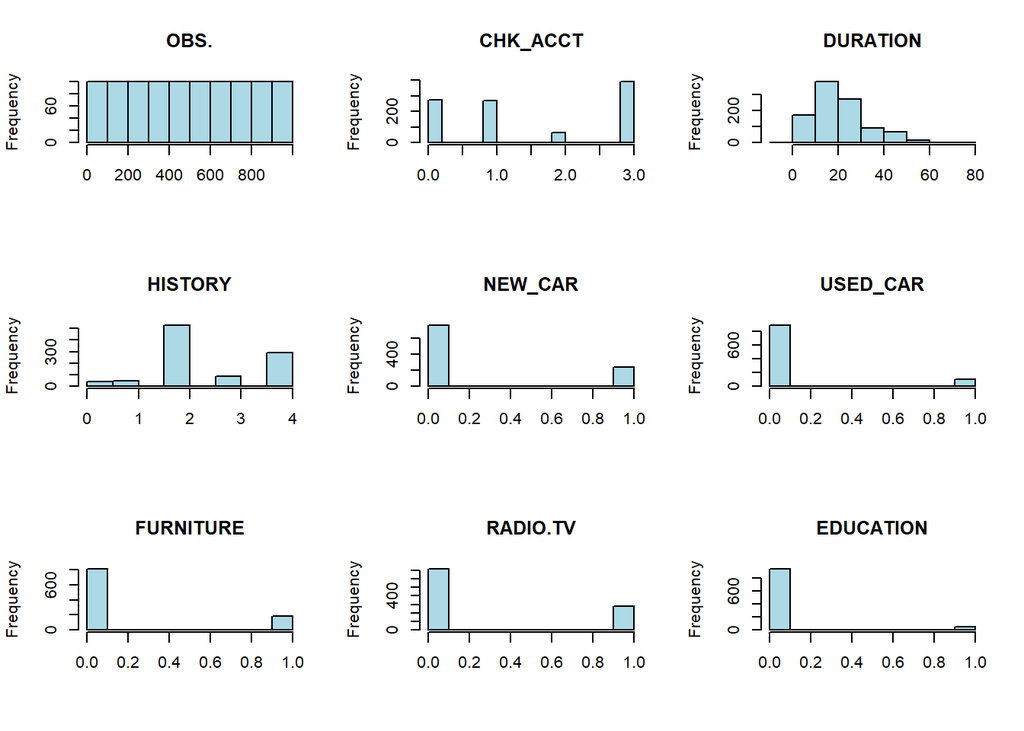

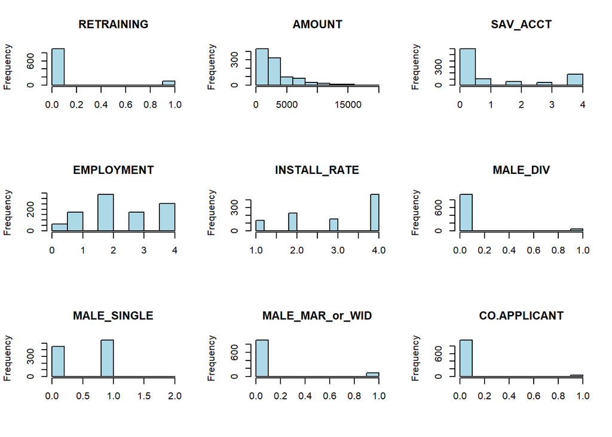

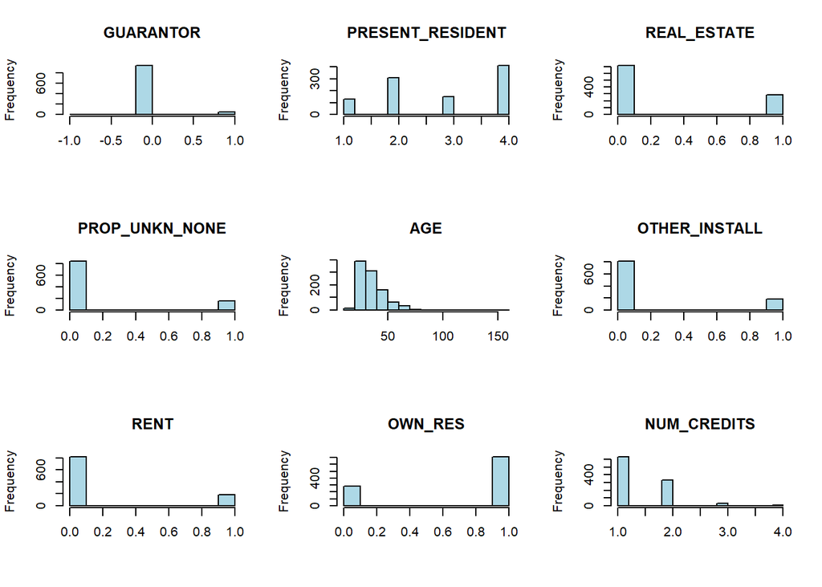

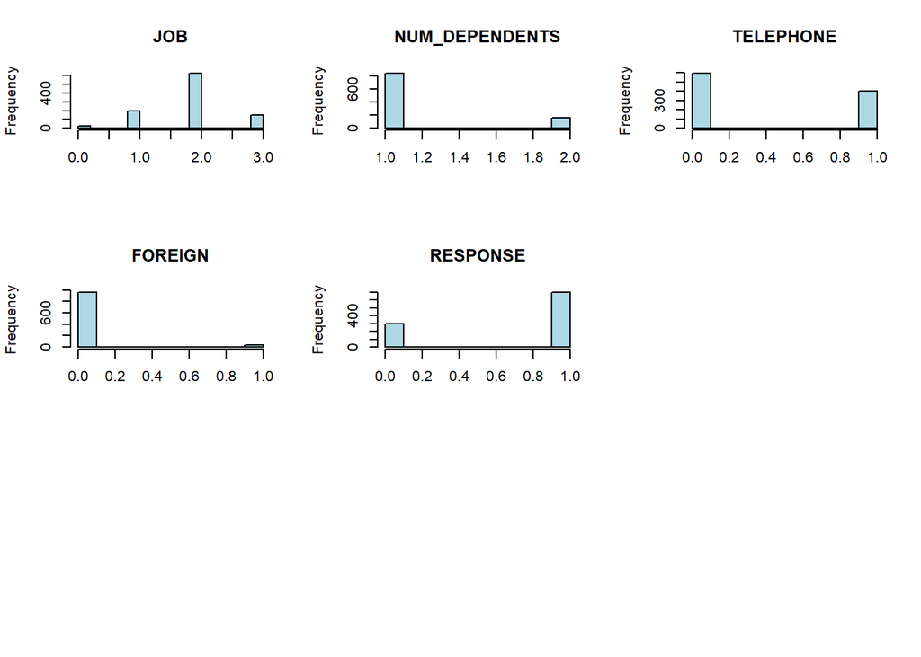

```r
#Histogram of frequency for every variable
par(mfrow=c(3,3)) # set up the layout of the plots
for (i in 1:32) {
  hist(credit_data[,i], main=colnames(credit_data)[i], xlab="", col="lightblue")
}
```

Those frequency histograms confirm us the problems with had earlier with our 2 variables `MAKE_SINGLE`and `GUARANTOR`.

So what to do ? As the missing/wrong values appears a few time in our dataset, we want to drop them and check if everything is alright now.

```r
# Drop rows with missing values in AGE
credit_data <- credit_data[!is.na(credit_data$AGE), ]

# Drop rows with AGE > 100
credit_data <- credit_data %>%
  filter(AGE <= 100)
# Drop rows where duration is negative
credit_data <- credit_data %>%
  filter(DURATION > 0)
# Drop rows with incorrect values in MALE_SINGLE
credit_data <- credit_data[credit_data$MALE_SINGLE <= 1, ]

# Drop rows with incorrect values in GUARANTOR
credit_data <- credit_data[credit_data$GUARANTOR >= 0, ]

kable(summary(credit_data))
```

|  | OBS. | CHK_ACCT | DURATION | HISTORY | NEW_CAR | USED_CAR | FURNITURE | RADIO.TV | EDUCATION | RETRAINING | AMOUNT | SAV_ACCT | EMPLOYMENT | INSTALL_RATE | MALE_DIV | MALE_SINGLE | MALE_MAR_or_WID | CO.APPLICANT | GUARANTOR | PRESENT_RESIDENT | REAL_ESTATE | PROP_UNKN_NONE | AGE | OTHER_INSTALL | RENT | OWN_RES | NUM_CREDITS | JOB | NUM_DEPENDENTS | … |
| --- | --- | --- | --- | --- | --- | --- | --- | --- | --- | --- | --- | --- | --- | --- | --- | --- | --- | --- | --- | --- | --- | --- | --- | --- | --- | --- | --- | --- | --- | --- |
|  | Min. : 2.0 | Min. :0.000 | Min. : 4.00 | Min. :0.000 | Min. :0.0000 | Min. :0.0000 | Min. :0.0000 | Min. :0.000 | Min. :0.0000 | Min. :0.00000 | Min. : 250 | Min. :0.000 | Min. :0.000 | Min. :1.000 | Min. :0.0000 | Min. :0.0000 | Min. :0.00000 | Min. :0.00000 | Min. :0.00000 | Min. :1.000 | Min. :0.0000 | Min. :0.0000 | Min. :19.0 | Min. :0.0000 | Min. :0.0000 | Min. :0.0000 | Min. :1.000 | Min. :0.000 | Min. :1.000 | … |
|  | 1st Qu.: 255.2 | 1st Qu.:0.000 | 1st Qu.:12.00 | 1st Qu.:2.000 | 1st Qu.:0.0000 | 1st Qu.:0.0000 | 1st Qu.:0.0000 | 1st Qu.:0.000 | 1st Qu.:0.0000 | 1st Qu.:0.00000 | 1st Qu.: 1372 | 1st Qu.:0.000 | 1st Qu.:2.000 | 1st Qu.:2.000 | 1st Qu.:0.0000 | 1st Qu.:0.0000 | 1st Qu.:0.00000 | 1st Qu.:0.00000 | 1st Qu.:0.00000 | 1st Qu.:2.000 | 1st Qu.:0.0000 | 1st Qu.:0.0000 | 1st Qu.:27.0 | 1st Qu.:0.0000 | 1st Qu.:0.0000 | 1st Qu.:0.0000 | 1st Qu.:1.000 | 1st Qu.:2.000 | 1st Qu.:1.000 | … |
|  | Median : 500.5 | Median :1.000 | Median :18.00 | Median :2.000 | Median :0.0000 | Median :0.0000 | Median :0.0000 | Median :0.000 | Median :0.0000 | Median :0.00000 | Median : 2324 | Median :0.000 | Median :2.000 | Median :3.000 | Median :0.0000 | Median :1.0000 | Median :0.00000 | Median :0.00000 | Median :0.00000 | Median :3.000 | Median :0.0000 | Median :0.0000 | Median :33.0 | Median :0.0000 | Median :0.0000 | Median :1.0000 | Median :1.000 | Median :2.000 | Median :1.000 | … |
|  | Mean : 501.7 | Mean :1.582 | Mean :20.95 | Mean :2.542 | Mean :0.2332 | Mean :0.1039 | Mean :0.1833 | Mean :0.279 | Mean :0.0499 | Mean :0.09572 | Mean : 3263 | Mean :1.101 | Mean :2.382 | Mean :2.974 | Mean :0.0499 | Mean :0.5458 | Mean :0.09165 | Mean :0.04175 | Mean :0.05295 | Mean :2.844 | Mean :0.2811 | Mean :0.1507 | Mean :35.4 | Mean :0.1823 | Mean :0.1813 | Mean :0.7118 | Mean :1.409 | Mean :1.899 | Mean :1.155 | … |
|  | 3rd Qu.: 748.8 | 3rd Qu.:3.000 | 3rd Qu.:24.00 | 3rd Qu.:4.000 | 3rd Qu.:0.0000 | 3rd Qu.:0.0000 | 3rd Qu.:0.0000 | 3rd Qu.:1.000 | 3rd Qu.:0.0000 | 3rd Qu.:0.00000 | 3rd Qu.: 3966 | 3rd Qu.:2.000 | 3rd Qu.:3.750 | 3rd Qu.:4.000 | 3rd Qu.:0.0000 | 3rd Qu.:1.0000 | 3rd Qu.:0.00000 | 3rd Qu.:0.00000 | 3rd Qu.:0.00000 | 3rd Qu.:4.000 | 3rd Qu.:1.0000 | 3rd Qu.:0.0000 | 3rd Qu.:42.0 | 3rd Qu.:0.0000 | 3rd Qu.:0.0000 | 3rd Qu.:1.0000 | 3rd Qu.:2.000 | 3rd Qu.:2.000 | 3rd Qu.:1.000 | … |
|  | Max. :1000.0 | Max. :3.000 | Max. :72.00 | Max. :4.000 | Max. :1.0000 | Max. :1.0000 | Max. :1.0000 | Max. :1.000 | Max. :1.0000 | Max. :1.00000 | Max. :18424 | Max. :4.000 | Max. :4.000 | Max. :4.000 | Max. :1.0000 | Max. :1.0000 | Max. :1.00000 | Max. :1.00000 | Max. :1.00000 | Max. :4.000 | Max. :1.0000 | Max. :1.0000 | Max. :75.0 | Max. :1.0000 | Max. :1.0000 | Max. :1.0000 | Max. :4.000 | Max. :3.000 | Max. :2.000 | … |

Everything is fine now

We do a correlation plot in order to find some correlation between our variables.

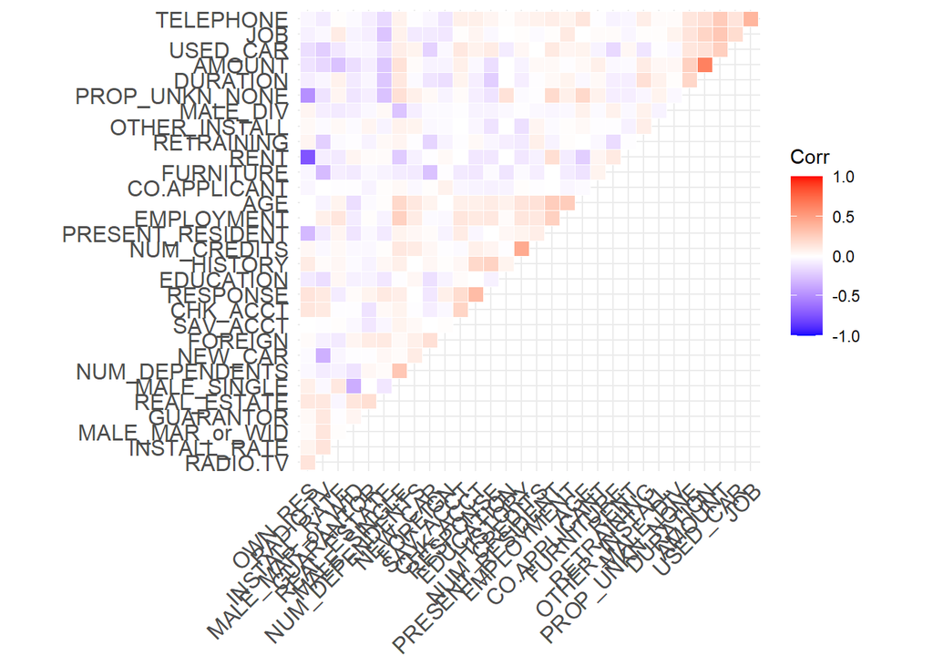

```r
# Select all columns except OBS
cols <- names(credit_data)[-1]

# Compute the correlation matrix
corr_mat <- cor(credit_data[, cols], use="complete.obs")

# Create the correlation plot
ggcorrplot(corr_mat, hc.order = TRUE, type = "upper", outline.col = "white")
```

# Proposition to modify the data

One option could be to create a new variable called `MARITAL_STATUS` that combines the information from the `MALE_SINGLE`, `MALE_DIV`, and `MALE_MAR_WID` variables. For example, if all three variables are 0, then the `MARITAL_STATUS` variable could be “unknown” or “not specified.” Alternatively, if only one of the three variables is 1, then the `MARITAL_STATUS` variable could be set to “single”, “divorced” or “married/widowed” accordingly.

```r
credit_data$MARITAL_STATUS <- NA
credit_data$MARITAL_STATUS[credit_data$MALE_SINGLE == 1] <- 1 # Single
credit_data$MARITAL_STATUS[credit_data$MALE_DIV == 1] <- 2 # Divorced
credit_data$MARITAL_STATUS[credit_data$MALE_MAR_or_WID == 1] <- 3 # Married/Widowed
credit_data$MARITAL_STATUS[credit_data$MALE_SINGLE + credit_data$MALE_DIV + credit_data$MALE_MAR_or_WID == 0] <- 0 # Unknown/Not Specified
credit_data$MARITAL_STATUS <- as.factor(credit_data$MARITAL_STATUS)
levels(credit_data$MARITAL_STATUS) <- c("Unknown/Not Specified", "Single", "Divorced", "Married/Widowed")

#Drop the columns
credit_data_mod <- credit_data %>%
  select(-MALE_SINGLE, -MALE_DIV, -MALE_MAR_or_WID)
```

Let us combine other variables

```r
# Combine purpose of credit variables
credit_data_mod$CREDIT_PURPOSE <- NA
credit_data_mod$CREDIT_PURPOSE[credit_data_mod$NEW_CAR == 1] <- "New Car"
credit_data_mod$CREDIT_PURPOSE[credit_data_mod$USED_CAR == 1] <- "Used Car"
credit_data_mod$CREDIT_PURPOSE[credit_data_mod$FURNITURE == 1] <- "Furniture"
credit_data_mod$CREDIT_PURPOSE[credit_data_mod$`RADIO.TV` == 1] <- "Radio.TV"
credit_data_mod$CREDIT_PURPOSE[credit_data_mod$EDUCATION == 1] <- "Education"
credit_data_mod$CREDIT_PURPOSE[credit_data_mod$RETRAINING == 1] <- "Retraining"
credit_data_mod$CREDIT_PURPOSE[is.na(credit_data_mod$CREDIT_PURPOSE)] <- "Other"
credit_data_mod$CREDIT_PURPOSE <- as.factor(credit_data_mod$CREDIT_PURPOSE)

# Combine housing variables
credit_data_mod$HOUSING <- NA
credit_data_mod$HOUSING[credit_data_mod$RENT == 1] <- "Rent"
credit_data_mod$HOUSING[credit_data_mod$OWN_RES == 1] <- "Own Residence"
credit_data_mod$HOUSING[is.na(credit_data_mod$HOUSING)] <- "Unknown"
credit_data_mod$HOUSING <- as.factor(credit_data_mod$HOUSING)

# Combine property ownership variables
credit_data_mod$PROPERTY_OWNERSHIP <- NA
credit_data_mod$PROPERTY_OWNERSHIP[credit_data_mod$REAL_ESTATE == 1] <- "Owns Real Estate"
credit_data_mod$PROPERTY_OWNERSHIP[credit_data_mod$PROP_UNKN_NONE == 1] <- "No Property/Unknown"
credit_data_mod$PROPERTY_OWNERSHIP[is.na(credit_data_mod$PROPERTY_OWNERSHIP)] <- "Other"
credit_data_mod$PROPERTY_OWNERSHIP <- as.factor(credit_data_mod$PROPERTY_OWNERSHIP)

#Drop the original columns
credit_data_mod <- credit_data_mod %>%
  select(-c(NEW_CAR, USED_CAR, FURNITURE, `RADIO.TV`, EDUCATION, RETRAINING, RENT, OWN_RES, REAL_ESTATE, PROP_UNKN_NONE))
```

We are going to drop some variables. - OBS is a variable that does not make sense to use for our logistic regression. - Foreign is a discriminant variable that is not usable in Europe. - Telephone is a veraible that a techincally legally isues to be used.

```r
credit_data_mod <- credit_data_mod %>%
  select(-OBS., -TELEPHONE, -FOREIGN)
```

# Modeling

## Logistic regression

```r
# Split the data into training and testing sets
set.seed(42)
split <- sample.split(credit_data_mod$RESPONSE, SplitRatio = 0.7)
train_data <- credit_data_mod[split, ]
test_data <- credit_data_mod[!split, ]

# Fit the logistic regression model
logistic_model <- glm(RESPONSE ~ ., data = train_data, family = "binomial")

# Display the model summary
summary(logistic_model)
```

```
##
## Call:
## glm(formula = RESPONSE ~ ., family = "binomial", data = train_data)
##
## Deviance Residuals:
##     Min       1Q   Median       3Q      Max
## -2.5729  -0.7084   0.4036   0.7083   2.1639
##
## Coefficients:
##                                      Estimate Std. Error z value Pr(>|z|)
## (Intercept)                         6.668e-01  9.975e-01   0.668 0.503838
## CHK_ACCT                            4.725e-01  8.640e-02   5.469 4.51e-08 ***
## DURATION                           -3.833e-02  1.080e-02  -3.548 0.000388 ***
## HISTORY                             3.559e-01  1.038e-01   3.428 0.000608 ***
## AMOUNT                             -1.045e-04  5.171e-05  -2.022 0.043189 *
## SAV_ACCT                            2.913e-01  7.510e-02   3.878 0.000105 ***
## EMPLOYMENT                          1.286e-01  9.494e-02   1.354 0.175652
## INSTALL_RATE                       -3.636e-01  1.042e-01  -3.491 0.000481 ***
## CO.APPLICANT                       -4.735e-01  4.952e-01  -0.956 0.339033
## GUARANTOR                           8.402e-01  4.916e-01   1.709 0.087413 .
## PRESENT_RESIDENT                   -1.121e-01  1.024e-01  -1.095 0.273587
## AGE                                 1.589e-02  1.067e-02   1.489 0.136583
## OTHER_INSTALL                      -5.700e-01  2.424e-01  -2.351 0.018705 *
## NUM_CREDITS                        -2.613e-01  1.973e-01  -1.324 0.185392
## JOB                                 1.253e-01  1.695e-01   0.739 0.459762
## NUM_DEPENDENTS                     -3.936e-01  3.091e-01  -1.273 0.202948
## MARITAL_STATUSSingle                4.893e-01  2.532e-01   1.932 0.053301 .
## MARITAL_STATUSDivorced             -7.986e-01  4.653e-01  -1.716 0.086120 .
## MARITAL_STATUSMarried/Widowed      -5.971e-02  3.701e-01  -0.161 0.871836
## CREDIT_PURPOSEFurniture             8.048e-01  4.885e-01   1.648 0.099437 .
## CREDIT_PURPOSENew Car               1.574e-01  4.664e-01   0.337 0.735783
## CREDIT_PURPOSEOther                 6.840e-01  5.773e-01   1.185 0.236090
## CREDIT_PURPOSERadio.TV              9.087e-01  4.804e-01   1.892 0.058528 .
## CREDIT_PURPOSERetraining            7.219e-01  5.431e-01   1.329 0.183789
## CREDIT_PURPOSEUsed Car              1.621e+00  5.629e-01   2.879 0.003985 **
## HOUSINGRent                        -7.413e-01  2.717e-01  -2.728 0.006365 **
## HOUSINGUnknown                     -3.519e-01  6.028e-01  -0.584 0.559379
## PROPERTY_OWNERSHIPOther             2.573e-01  5.276e-01   0.488 0.625714
## PROPERTY_OWNERSHIPOwns Real Estate  8.538e-02  5.524e-01   0.155 0.877162
## ---
## Signif. codes:  0 '***' 0.001 '**' 0.01 '*' 0.05 '.' 0.1 ' ' 1
##
## (Dispersion parameter for binomial family taken to be 1)
##
##     Null deviance: 839.16  on 686  degrees of freedom
## Residual deviance: 625.39  on 658  degrees of freedom
## AIC: 683.39
##
## Number of Fisher Scoring iterations: 5
```

```r
# Make predictions on the test data
predicted_probs <- predict(logistic_model, newdata = test_data, type = "response")

# Convert probabilities to binary predictions (0 or 1)
predicted_classes <- ifelse(predicted_probs > 0.5, 1, 0)

# Calculate the accuracy of the model
accuracy <- mean(predicted_classes == test_data$RESPONSE)
cat("Accuracy:", accuracy, "\n")
```

```
## Accuracy: 0.7389831
```

```r
# Perform stepwise regression
stepwise_model <- step(logistic_model, direction = "both")
```

```
## Start:  AIC=683.39
## RESPONSE ~ CHK_ACCT + DURATION + HISTORY + AMOUNT + SAV_ACCT +
##     EMPLOYMENT + INSTALL_RATE + CO.APPLICANT + GUARANTOR + PRESENT_RESIDENT +
##     AGE + OTHER_INSTALL + NUM_CREDITS + JOB + NUM_DEPENDENTS +
##     MARITAL_STATUS + CREDIT_PURPOSE + HOUSING + PROPERTY_OWNERSHIP
##
##                      Df Deviance    AIC
## - PROPERTY_OWNERSHIP  2   626.04 680.04
## - JOB                 1   625.94 681.94
## - CO.APPLICANT        1   626.29 682.29
## - PRESENT_RESIDENT    1   626.59 682.59
## - NUM_DEPENDENTS      1   626.99 682.99
## - NUM_CREDITS         1   627.15 683.15
## - EMPLOYMENT          1   627.22 683.22
## <none>                    625.39 683.39
## - AGE                 1   627.65 683.65
## - GUARANTOR           1   628.54 684.54
## - AMOUNT              1   629.55 685.55
## - HOUSING             2   632.81 686.81
## - OTHER_INSTALL       1   630.87 686.87
## - MARITAL_STATUS      3   635.67 687.67
## - CREDIT_PURPOSE      6   642.41 688.41
## - HISTORY             1   637.60 693.60
## - INSTALL_RATE        1   638.10 694.10
## - DURATION            1   638.23 694.23
## - SAV_ACCT            1   641.82 697.82
## - CHK_ACCT            1   657.10 713.10
##
## Step:  AIC=680.04
## RESPONSE ~ CHK_ACCT + DURATION + HISTORY + AMOUNT + SAV_ACCT +
##     EMPLOYMENT + INSTALL_RATE + CO.APPLICANT + GUARANTOR + PRESENT_RESIDENT +
##     AGE + OTHER_INSTALL + NUM_CREDITS + JOB + NUM_DEPENDENTS +
##     MARITAL_STATUS + CREDIT_PURPOSE + HOUSING
##
##                      Df Deviance    AIC
## - JOB                 1   626.74 678.74
## - CO.APPLICANT        1   627.09 679.09
## - PRESENT_RESIDENT    1   627.09 679.09
## - NUM_DEPENDENTS      1   627.62 679.62
## - NUM_CREDITS         1   627.73 679.73
```

[output cut: 165 more lines]

```
## - GUARANTOR           1   636.80 676.80
## + JOB                 1   632.89 676.89
## - AMOUNT              1   637.07 677.07
## + PRESENT_RESIDENT    1   633.17 677.17
## + CO.APPLICANT        1   633.18 677.18
## - MARITAL_STATUS      3   642.04 678.04
## + PROPERTY_OWNERSHIP  2   633.19 679.19
## - OTHER_INSTALL       1   639.41 679.41
## - CREDIT_PURPOSE      6   652.54 682.54
## - HOUSING             2   646.57 684.57
## - INSTALL_RATE        1   644.64 684.64
## - HISTORY             1   645.02 685.02
## - DURATION            1   647.44 687.44
## - SAV_ACCT            1   650.05 690.05
## - CHK_ACCT            1   667.96 707.96
```

```r
# Summary of the final model
summary(stepwise_model)
```

```
##
## Call:
## glm(formula = RESPONSE ~ CHK_ACCT + DURATION + HISTORY + AMOUNT +
##     SAV_ACCT + EMPLOYMENT + INSTALL_RATE + GUARANTOR + OTHER_INSTALL +
##     MARITAL_STATUS + CREDIT_PURPOSE + HOUSING, family = "binomial",
##     data = train_data)
##
## Deviance Residuals:
##     Min       1Q   Median       3Q      Max
## -2.4631  -0.7405   0.4214   0.7261   2.2655
##
## Coefficients:
##                                 Estimate Std. Error z value Pr(>|z|)
## (Intercept)                    4.486e-01  6.306e-01   0.711 0.476895
## CHK_ACCT                       4.853e-01  8.576e-02   5.659 1.52e-08 ***
## DURATION                      -3.878e-02  1.063e-02  -3.648 0.000264 ***
## HISTORY                        3.045e-01  9.257e-02   3.289 0.001005 **
## AMOUNT                        -8.751e-05  4.927e-05  -1.776 0.075690 .
## SAV_ACCT                       2.860e-01  7.420e-02   3.855 0.000116 ***
## EMPLOYMENT                     1.318e-01  8.936e-02   1.475 0.140091
## INSTALL_RATE                  -3.263e-01  1.012e-01  -3.224 0.001265 **
## GUARANTOR                      8.062e-01  4.883e-01   1.651 0.098738 .
## OTHER_INSTALL                 -5.614e-01  2.372e-01  -2.367 0.017926 *
## MARITAL_STATUSSingle           4.104e-01  2.393e-01   1.715 0.086406 .
## MARITAL_STATUSDivorced        -7.035e-01  4.575e-01  -1.538 0.124063
## MARITAL_STATUSMarried/Widowed -3.427e-02  3.667e-01  -0.093 0.925529
## CREDIT_PURPOSEFurniture        8.426e-01  4.778e-01   1.764 0.077780 .
## CREDIT_PURPOSENew Car          1.929e-01  4.607e-01   0.419 0.675376
## CREDIT_PURPOSEOther            6.937e-01  5.683e-01   1.221 0.222211
## CREDIT_PURPOSERadio.TV         9.718e-01  4.694e-01   2.070 0.038408 *
## CREDIT_PURPOSERetraining       7.579e-01  5.326e-01   1.423 0.154690
## CREDIT_PURPOSEUsed Car         1.655e+00  5.513e-01   3.002 0.002683 **
## HOUSINGRent                   -8.789e-01  2.570e-01  -3.420 0.000626 ***
## HOUSINGUnknown                -5.289e-01  3.354e-01  -1.577 0.114822
## ---
## Signif. codes:  0 '***' 0.001 '**' 0.01 '*' 0.05 '.' 0.1 ' ' 1
##
## (Dispersion parameter for binomial family taken to be 1)
##
##     Null deviance: 839.16  on 686  degrees of freedom
## Residual deviance: 633.86  on 666  degrees of freedom
## AIC: 675.86
##
## Number of Fisher Scoring iterations: 5
```

Here, we will keep the variables that are the most significant so the one with the stars as they are statistically significant.

Let’s see if the variables have multicollinearity:

```r
vif_model <- vif(stepwise_model)
print(vif_model)
```

```
##                    GVIF Df GVIF^(1/(2*Df))
## CHK_ACCT       1.078911  1        1.038706
## DURATION       1.814394  1        1.346995
## HISTORY        1.063749  1        1.031382
## AMOUNT         2.221320  1        1.490409
## SAV_ACCT       1.078209  1        1.038368
## EMPLOYMENT     1.122763  1        1.059605
## INSTALL_RATE   1.308200  1        1.143766
## GUARANTOR      1.070530  1        1.034664
## OTHER_INSTALL  1.048013  1        1.023725
## MARITAL_STATUS 1.340401  3        1.050040
## CREDIT_PURPOSE 1.602158  6        1.040061
## HOUSING        1.347383  2        1.077390
```

As we can see, all the values are under `under 5` so there is no multicollinearity problem.

```r
set.seed(42)

# Generate predicted probabilities for the test data
test_probs <- predict(stepwise_model, newdata = test_data, type = "response")
# Convert probabilities to binary predictions
test_preds <- ifelse(test_probs > 0.5, 1, 0)
# Calculate accuracy
confusion_matrix <- table(Predicted = test_preds, Actual = test_data$RESPONSE)
print(confusion_matrix)
```

```
##          Actual
## Predicted   0   1
##         0  39  19
##         1  50 187
```

```r
# Calculate accuracy
accuracy <- mean(test_preds == test_data$RESPONSE)
cat("Accuracy:", accuracy, "\n")
```

```
## Accuracy: 0.7661017
```

```r
# Sensitivity
sensitivity <- confusion_matrix[2, 2] / sum(confusion_matrix[, 2])
cat("Sensitivity:", sensitivity, "\n")
```

```
## Sensitivity: 0.907767
```

```r
# Specificity
specificity <- confusion_matrix[1, 1] / sum(confusion_matrix[, 1])
cat("Specifity:", specificity, "\n")
```

```
## Specifity: 0.4382022
```

In this case, the model is of course simple so we have a pretty low specificity. That means that we are predicting bad customers pretty poorly.

```r
set.seed(42)

library(pROC)
```

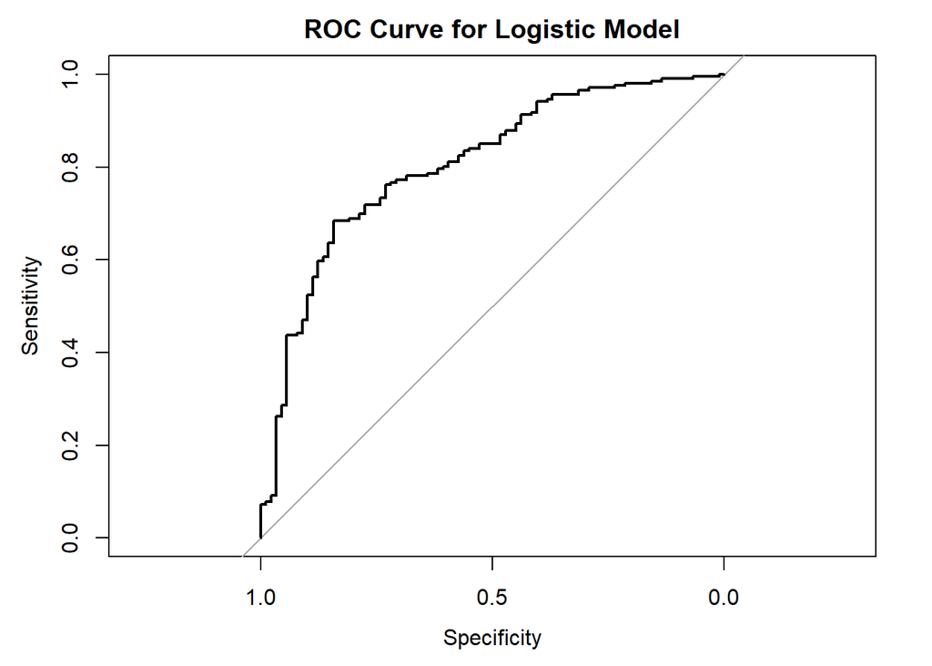

```r
# Compute ROC curve
roc_obj <- roc(test_data$RESPONSE, test_probs)
# Plot ROC curve
plot(roc_obj, main="ROC Curve for Logistic Model")
```

```r
cat("AUC:", auc(roc_obj), "\n")
```

```
## AUC: 0.8051162
```

It is clear we cannot choose this model because the specificity (here the values swapped but it is equal to the sensitivity in the rest of the project) is too low.

Based on the Logistic Regression, we will keep those variables which have the most significance for our model.

```r
#Let's drop the columns we don't need
credit_data <- credit_data %>%
  select(RESPONSE, CHK_ACCT, DURATION, HISTORY, NEW_CAR, USED_CAR, SAV_ACCT, INSTALL_RATE, OTHER_INSTALL, OWN_RES)

#we deleted deleted guarantor, real estate plus the ones before

head(credit_data)
```

```
##   RESPONSE CHK_ACCT DURATION HISTORY NEW_CAR USED_CAR SAV_ACCT INSTALL_RATE
## 1        0        1       48       2       0        0        0            2
## 2        1        3       12       4       0        0        0            2
## 3        1        0       42       2       0        0        0            2
## 4        0        0       24       3       1        0        0            3
## 5        1        3       36       2       0        0        4            2
## 6        1        3       24       2       0        0        2            3
##   OTHER_INSTALL OWN_RES
## 1             0       1
## 2             0       1
## 3             0       0
## 4             0       0
## 5             0       0
## 6             0       1
```

```r
#New training/test set
split <- sample.split(credit_data$RESPONSE, SplitRatio = 0.7)
train_data <- credit_data[split, ]
test_data <- credit_data[!split, ]
```

```r
# Convert RESPONSE to a factor and adjust the levels for our next models
train_data$RESPONSE <- as.factor(train_data$RESPONSE)
levels(train_data$RESPONSE) <- c("Bad", "Good")

test_data$RESPONSE <- as.factor(test_data$RESPONSE)
levels(test_data$RESPONSE) <- c("Bad", "Good")
```

For the next models, we will use the caret library in order to calculate those. We choose some parameters that will remain constant for the models :

```r
# Set up the trainControl object
ctrl <- trainControl(method = "repeatedcv", number = 10, repeats = 10, verboseIter = FALSE, sampling = "down")
```

## Random Forests

For this model we are going to train 2 different sub models : one that is normal and another with automatic hyper parameters findings.

```r
set.seed(42)

# Train the random forest model using caret

rf_model <- train(RESPONSE ~ ., data = train_data, method = "rf", trControl = ctrl)

# Print the model
print(rf_model)
```

```
## Random Forest
##
## 687 samples
##   9 predictor
##   2 classes: 'Bad', 'Good'
##
## No pre-processing
## Resampling: Cross-Validated (10 fold, repeated 10 times)
## Summary of sample sizes: 619, 618, 619, 618, 618, 618, ...
## Addtional sampling using down-sampling
##
## Resampling results across tuning parameters:
##
##   mtry  Accuracy   Kappa
##   2     0.6813364  0.3290823
##   5     0.6690558  0.3010078
##   9     0.6514956  0.2690712
##
## Accuracy was used to select the optimal model using the largest value.
## The final value used for the model was mtry = 2.
```

```r
# Make predictions on the test dataset
predictions <- predict(rf_model, test_data)

# Evaluate the model using a confusion matrix
cm <- confusionMatrix(predictions, test_data$RESPONSE)
print(cm)
```

```
## Confusion Matrix and Statistics
##
##           Reference
## Prediction Bad Good
##       Bad   63   64
##       Good  26  142
##
##                Accuracy : 0.6949
##                  95% CI : (0.6389, 0.747)
##     No Information Rate : 0.6983
##     P-Value [Acc > NIR] : 0.5786
##
##                   Kappa : 0.3542
##
##  Mcnemar's Test P-Value : 9.614e-05
##
##             Sensitivity : 0.7079
##             Specificity : 0.6893
##          Pos Pred Value : 0.4961
##          Neg Pred Value : 0.8452
##              Prevalence : 0.3017
##          Detection Rate : 0.2136
##    Detection Prevalence : 0.4305
##       Balanced Accuracy : 0.6986
##
##        'Positive' Class : Bad
##
```

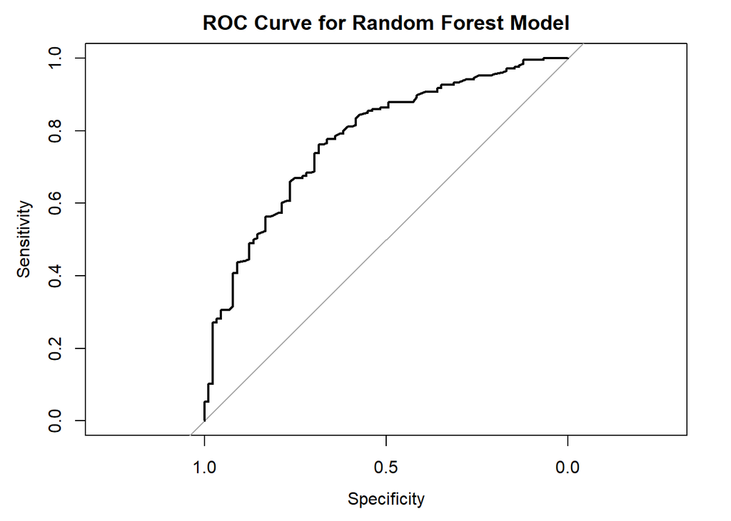

```r
# Compute the predicted probabilities of the positive class
predicted_probs <- predict(rf_model, newdata = test_data, type = "prob")[,2]

# Create the ROC curve
roc_obj_rf <- roc(test_data$RESPONSE, predicted_probs)
# Plot the ROC curve
plot(roc_obj_rf, main="ROC Curve for Random Forest Model")
```

```r
cat("AUC:", auc(roc_obj_rf), "\n")
```

```
## AUC: 0.777299
```

We let caret choose the optimal parameters with grid.

```r
# Define the search grid for hyperparameters
set.seed(42)

tune_grid <- expand.grid(mtry = seq(2, 29, 2))

# Set up the training control with cross-validation and repeated sampling
train_control <- trainControl(method = "repeatedcv",
                              number = 10,
                              repeats = 10,
                              sampling = "down",
                              search = "grid")

# Train the Random Forest model with hyperparameter tuning
tuned_rf_model <- train(RESPONSE ~ .,
                        data = train_data,
                        method = "rf",
                        metric = "Accuracy",
                        trControl = train_control,
                        tuneGrid = tune_grid)

# Print the results
print(tuned_rf_model)
```

```
## Random Forest
##
## 687 samples
##   9 predictor
##   2 classes: 'Bad', 'Good'
##
## No pre-processing
## Resampling: Cross-Validated (10 fold, repeated 10 times)
## Summary of sample sizes: 619, 618, 619, 618, 618, 618, ...
## Addtional sampling using down-sampling
##
## Resampling results across tuning parameters:
##
##   mtry  Accuracy   Kappa
##    2    0.6837809  0.3345726
##    4    0.6664749  0.2958602
##    6    0.6610675  0.2887911
##    8    0.6530574  0.2685741
##   10    0.6561481  0.2781000
##   12    0.6441914  0.2574104
##   14    0.6544111  0.2731046
##   16    0.6520563  0.2736153
##   18    0.6550914  0.2781897
##   20    0.6519091  0.2697170
##   22    0.6507414  0.2689321
##   24    0.6541300  0.2739579
##   26    0.6516451  0.2703629
##   28    0.6498863  0.2665507
##
## Accuracy was used to select the optimal model using the largest value.
## The final value used for the model was mtry = 2.
```

```r
# Obtain the best model
best_rf_model <- tuned_rf_model

# Make predictions on the test dataset
predictions <- predict(best_rf_model, test_data)

# Evaluate the model using a confusion matrix
cm <- confusionMatrix(predictions, test_data$RESPONSE)
print(cm)
```

```
## Confusion Matrix and Statistics
##
##           Reference
## Prediction Bad Good
##       Bad   63   67
##       Good  26  139
##
##                Accuracy : 0.6847
##                  95% CI : (0.6284, 0.7374)
##     No Information Rate : 0.6983
##     P-Value [Acc > NIR] : 0.7178
##
##                   Kappa : 0.3384
##
##  Mcnemar's Test P-Value : 3.357e-05
##
##             Sensitivity : 0.7079
##             Specificity : 0.6748
##          Pos Pred Value : 0.4846
##          Neg Pred Value : 0.8424
##              Prevalence : 0.3017
##          Detection Rate : 0.2136
##    Detection Prevalence : 0.4407
##       Balanced Accuracy : 0.6913
##
##        'Positive' Class : Bad
##
```

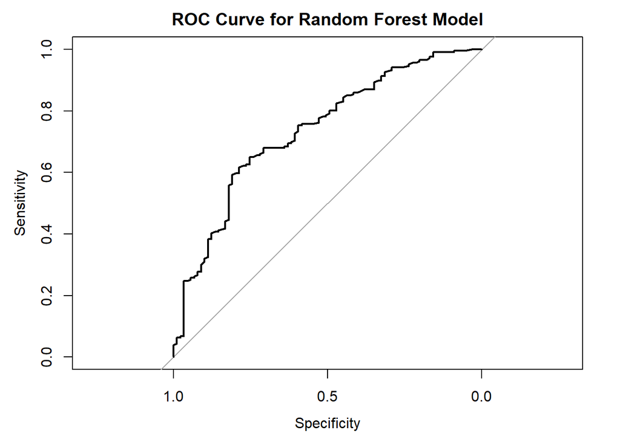

```r
# Compute the predicted probabilities of the positive class
tuned_predicted_probs <- predict(tuned_rf_model, newdata = test_data, type = "prob")[,2]

# Create the ROC curve
tuned_roc_obj_rf <- roc(test_data$RESPONSE, tuned_predicted_probs)
# Plot the ROC curve
plot(tuned_roc_obj_rf, main="ROC Curve for Random Forest Model")
```

```r
cat("AUC:", auc(tuned_roc_obj_rf), "\n")
```

```
## AUC: 0.7363641
```

You can see the importance of each variable in the model. As we can see, the type car isn’t as useful to predict the risk of a person as duration is.

```r
print(varImp(rf_model))
```

```
## rf variable importance
##
##               Overall
## DURATION      100.000
## CHK_ACCT       79.542
## HISTORY        42.884
## INSTALL_RATE   31.358
## SAV_ACCT       27.682
## OWN_RES        10.440
## OTHER_INSTALL   4.805
## USED_CAR        0.543
## NEW_CAR         0.000
```

We have better results overall and better AUC for our model without the hyperparameter tweek.

## LDA/QDA

```r
 set.seed(42)


# Train the LDA model with down-sampling
lda_model <- train(RESPONSE ~ . ,
                   data = train_data,
                   method = "lda",
                   trControl = ctrl)


# Print the model
print(lda_model)
```

```
## Linear Discriminant Analysis
##
## 687 samples
##   9 predictor
##   2 classes: 'Bad', 'Good'
##
## No pre-processing
## Resampling: Cross-Validated (10 fold, repeated 10 times)
## Summary of sample sizes: 619, 618, 619, 618, 618, 618, ...
## Addtional sampling using down-sampling
##
## Resampling results:
##
##   Accuracy   Kappa
##   0.7238452  0.4016788
```

```r
#Make predictions on the test dataset
predictions_lda <- predict(lda_model, test_data)

# Evaluate the model using a confusion matrix
cm_lda <- confusionMatrix(predictions_lda, test_data$RESPONSE)
print(cm_lda)
```

```
## Confusion Matrix and Statistics
##
##           Reference
## Prediction Bad Good
##       Bad   57   61
##       Good  32  145
##
##                Accuracy : 0.6847
##                  95% CI : (0.6284, 0.7374)
##     No Information Rate : 0.6983
##     P-Value [Acc > NIR] : 0.717816
##
##                   Kappa : 0.3152
##
##  Mcnemar's Test P-Value : 0.003691
##
##             Sensitivity : 0.6404
##             Specificity : 0.7039
##          Pos Pred Value : 0.4831
##          Neg Pred Value : 0.8192
##              Prevalence : 0.3017
##          Detection Rate : 0.1932
##    Detection Prevalence : 0.4000
##       Balanced Accuracy : 0.6722
##
##        'Positive' Class : Bad
##
```

```r
# Train the LDA model with down-sampling
set.seed(42)

qda_model <- train(RESPONSE ~ . ,
                   data = train_data,
                   method = "qda",
                   trControl = ctrl)


# Print the model
print(qda_model)
```

```
## Quadratic Discriminant Analysis
##
## 687 samples
##   9 predictor
##   2 classes: 'Bad', 'Good'
##
## No pre-processing
## Resampling: Cross-Validated (10 fold, repeated 10 times)
## Summary of sample sizes: 619, 618, 619, 618, 618, 618, ...
## Addtional sampling using down-sampling
##
## Resampling results:
##
##   Accuracy   Kappa
##   0.6708241  0.3078722
```

```r
#Make predictions on the test dataset
predictions_qda <- predict(qda_model, test_data)

# Evaluate the model using a confusion matrix
cm_qda <- confusionMatrix(predictions_qda, test_data$RESPONSE)
print(cm_qda)
```

```
## Confusion Matrix and Statistics
##
##           Reference
## Prediction Bad Good
##       Bad   60   63
##       Good  29  143
##
##                Accuracy : 0.6881
##                  95% CI : (0.6319, 0.7406)
##     No Information Rate : 0.6983
##     P-Value [Acc > NIR] : 0.6738602
##
##                   Kappa : 0.3323
##
##  Mcnemar's Test P-Value : 0.0005807
##
##             Sensitivity : 0.6742
##             Specificity : 0.6942
##          Pos Pred Value : 0.4878
##          Neg Pred Value : 0.8314
##              Prevalence : 0.3017
##          Detection Rate : 0.2034
##    Detection Prevalence : 0.4169
##       Balanced Accuracy : 0.6842
##
##        'Positive' Class : Bad
##
```

```r
varImp(qda_model)
```

```
## ROC curve variable importance
##
##               Importance
## CHK_ACCT         100.000
## DURATION          70.016
## HISTORY           53.085
## SAV_ACCT          46.557
## OWN_RES           46.108
## OTHER_INSTALL     11.667
## INSTALL_RATE       8.914
## NEW_CAR            5.069
## USED_CAR           0.000
```

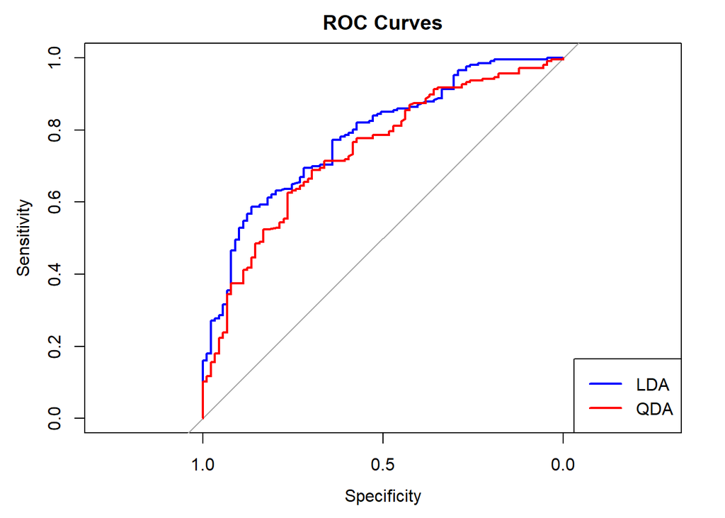

```r
# Make probability predictions
lda_prob_preds <- predict(lda_model, test_data, type = "prob")[,2]
qda_prob_preds <- predict(qda_model, test_data, type = "prob")[,2]

# Compute ROC curves
roc_obj_lda <- roc(test_data$RESPONSE, lda_prob_preds)
roc_obj_qda <- roc(test_data$RESPONSE, qda_prob_preds)
# Plot ROC curves
plot.roc(roc_obj_lda, main="ROC Curves", percent=TRUE, col="blue")
lines.roc(roc_obj_qda, percent=TRUE, col="red")

# Add legend
legend("bottomright", legend=c("LDA", "QDA"), col=c("blue", "red"), lwd=2)
```

```r
cat("AUC LDA:", auc(roc_obj_lda), "\n")
```

```
## AUC LDA: 0.7815534
```

```r
cat("AUC QDA:", auc(roc_obj_qda), "\n")
```

```
## AUC QDA: 0.7383004
```

## CART

```r
# Train the CART model using caret
 set.seed(42)

cart_model <- train(RESPONSE ~ ., data = train_data, method = "rpart", trControl = ctrl)

# Print the model
print(cart_model)
```

```
## CART
##
## 687 samples
##   9 predictor
##   2 classes: 'Bad', 'Good'
##
## No pre-processing
## Resampling: Cross-Validated (10 fold, repeated 10 times)
## Summary of sample sizes: 619, 618, 619, 618, 618, 618, ...
## Addtional sampling using down-sampling
##
## Resampling results across tuning parameters:
##
##   cp          Accuracy   Kappa
##   0.01699029  0.6712234  0.2981564
##   0.01941748  0.6684378  0.2959096
##   0.05339806  0.6262647  0.2712737
##
## Accuracy was used to select the optimal model using the largest value.
## The final value used for the model was cp = 0.01699029.
```

```r
#summary(cart_model)

# Make predictions on the test dataset
predictions_cart <- predict(cart_model, test_data)

# Evaluate the model using a confusion matrix
cm_cart <- confusionMatrix(predictions_cart, test_data$RESPONSE)
print(cm_cart)
```

```
## Confusion Matrix and Statistics
##
##           Reference
## Prediction Bad Good
##       Bad   57   58
##       Good  32  148
##
##                Accuracy : 0.6949
##                  95% CI : (0.6389, 0.747)
##     No Information Rate : 0.6983
##     P-Value [Acc > NIR] : 0.578596
##
##                   Kappa : 0.3314
##
##  Mcnemar's Test P-Value : 0.008408
##
##             Sensitivity : 0.6404
##             Specificity : 0.7184
##          Pos Pred Value : 0.4957
##          Neg Pred Value : 0.8222
##              Prevalence : 0.3017
##          Detection Rate : 0.1932
##    Detection Prevalence : 0.3898
##       Balanced Accuracy : 0.6794
##
##        'Positive' Class : Bad
##
```

Lets display the tree :

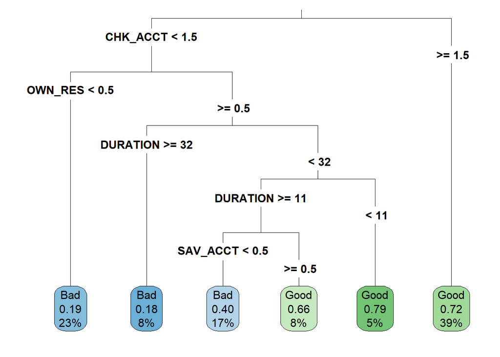

```r
# Create the plot
rpart.plot(cart_model$finalModel, roundint = FALSE, fallen.leaves = TRUE, type = 3)
```

```r
var_imp <- varImp(cart_model)
print(var_imp)
```

```
## rpart variable importance
##
##               Overall
## CHK_ACCT      100.000
## DURATION       86.721
## OWN_RES        67.387
## SAV_ACCT       63.498
## HISTORY        32.136
## NEW_CAR         7.102
## INSTALL_RATE    4.248
## USED_CAR        0.000
## OTHER_INSTALL   0.000
```

```r
library(pROC)
set.seed(42)

# Make predictions on the test dataset with type = "prob"
predictions_cart_probs <- predict(cart_model, test_data, type = "prob")

# The 'pROC' function expects a numeric vector, so we only need the probabilities for one class.

positive_class_probs <- predictions_cart_probs$'Bad'
roc_obj <- roc(test_data$RESPONSE, positive_class_probs)
```

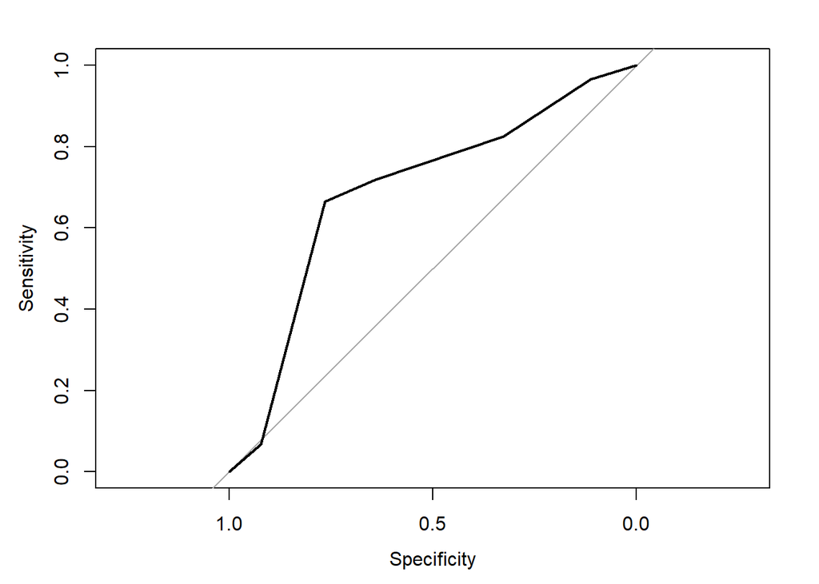

```r
plot(roc_obj)
```

```r
cat("AUC CART:", auc(roc_obj), "\n")
```

```
## AUC CART: 0.6903022
```

Let’s tweak the complexitiy parameter by pruning the tree.

```r
# Define a grid of cp values
cp_grid <- expand.grid(.cp = seq(0.01, 0.5, 0.01))

# Train the CART model using caret with the cp grid

cart_model_grid <- train(RESPONSE ~ .,
                    data = train_data,
                    method = "rpart",
                    trControl = ctrl,
                    tuneGrid = cp_grid)

# Print the model
print(cart_model_grid)
```

```
## CART
##
## 687 samples
##   9 predictor
##   2 classes: 'Bad', 'Good'
##
## No pre-processing
## Resampling: Cross-Validated (10 fold, repeated 10 times)
## Summary of sample sizes: 619, 618, 619, 618, 618, 618, ...
## Addtional sampling using down-sampling
##
## Resampling results across tuning parameters:
##
##   cp    Accuracy   Kappa
##   0.01  0.6722657  0.298224168
##   0.02  0.6613530  0.285557408
##   0.03  0.6508607  0.274828134
##   0.04  0.6325079  0.262291577
##   0.05  0.6262605  0.258481082
##   0.06  0.6178160  0.263133696
##   0.07  0.6138603  0.261641882
##   0.08  0.6103714  0.259165325
##   0.09  0.6081826  0.257482291
##   0.10  0.6081826  0.257482291
##   0.11  0.6081826  0.257482291
##   0.12  0.6081826  0.257482291
##   0.13  0.6081826  0.257482291
##   0.14  0.6081826  0.257482291
##   0.15  0.6081826  0.257482291
##   0.16  0.6081826  0.257482291
##   0.17  0.6081826  0.257482291
##   0.18  0.6081826  0.257482291
##   0.19  0.6081826  0.257482291
##   0.20  0.6081826  0.257482291
##   0.21  0.6081826  0.257482291
##   0.22  0.6081826  0.257482291
##   0.23  0.6049942  0.254216525
##   0.24  0.6049942  0.254216525
##   0.25  0.6049942  0.254216525
##   0.26  0.6020956  0.251468777
```

[output cut: 12 more lines]

```
##   0.39  0.3027238  0.002597701
##   0.40  0.3027238  0.002597701
##   0.41  0.2998252  0.000000000
##   0.42  0.2998252  0.000000000
##   0.43  0.2998252  0.000000000
##   0.44  0.2998252  0.000000000
##   0.45  0.2998252  0.000000000
##   0.46  0.2998252  0.000000000
##   0.47  0.2998252  0.000000000
##   0.48  0.2998252  0.000000000
##   0.49  0.2998252  0.000000000
##   0.50  0.2998252  0.000000000
##
## Accuracy was used to select the optimal model using the largest value.
## The final value used for the model was cp = 0.01.
```

```r
#summary(cart_model_grid)

# Make predictions on the test dataset
predictions_cart_grid <- predict(cart_model_grid, test_data)

# Evaluate the model using a confusion matrix
cm_cart_grid <- confusionMatrix(predictions_cart_grid, test_data$RESPONSE)
print(cm_cart_grid)
```

```
## Confusion Matrix and Statistics
##
##           Reference
## Prediction Bad Good
##       Bad   69   74
##       Good  20  132
##
##                Accuracy : 0.6814
##                  95% CI : (0.6249, 0.7342)
##     No Information Rate : 0.6983
##     P-Value [Acc > NIR] : 0.7586
##
##                   Kappa : 0.3549
##
##  Mcnemar's Test P-Value : 4.589e-08
##
##             Sensitivity : 0.7753
##             Specificity : 0.6408
##          Pos Pred Value : 0.4825
##          Neg Pred Value : 0.8684
##              Prevalence : 0.3017
##          Detection Rate : 0.2339
##    Detection Prevalence : 0.4847
##       Balanced Accuracy : 0.7080
##
##        'Positive' Class : Bad
##
```

Let’s display the tree :

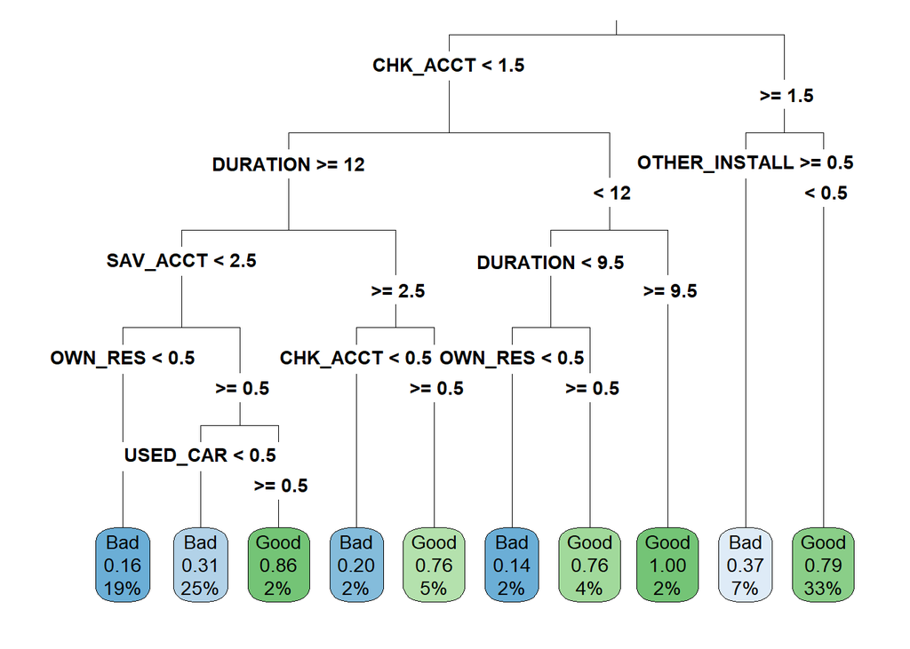

```r
# Create the plot
rpart.plot(cart_model_grid$finalModel, roundint = FALSE, fallen.leaves = TRUE, type = 3)
```

Better model than before since it is more complexe and has more nods.

```r
var_imp <- varImp(cart_model_grid)
print(var_imp)
```

```
## rpart variable importance
##
##               Overall
## CHK_ACCT      100.000
## DURATION       99.494
## OWN_RES        86.719
## HISTORY        60.677
## SAV_ACCT       54.139
## OTHER_INSTALL  18.559
## NEW_CAR         7.115
## USED_CAR        4.689
## INSTALL_RATE    0.000
```

## Neural Network

```r
# Train the 1st NN
 set.seed(42)

ctrl <- trainControl(sampling = "down",
                     savePredictions = "final")
nn_model <- train(RESPONSE ~ .,
                  data = train_data,
                  method = "nnet",
                  trControl = ctrl,
                  linout = FALSE,
                  trace = FALSE)

# Print the model
print(nn_model)
```

```
## Neural Network
##
## 687 samples
##   9 predictor
##   2 classes: 'Bad', 'Good'
##
## No pre-processing
## Resampling: Bootstrapped (25 reps)
## Summary of sample sizes: 687, 687, 687, 687, 687, 687, ...
## Addtional sampling using down-sampling
##
## Resampling results across tuning parameters:
##
##   size  decay  Accuracy   Kappa
##   1     0e+00  0.6552667  0.2963597
##   1     1e-04  0.6864025  0.2791401
##   1     1e-01  0.7101957  0.3661209
##   3     0e+00  0.6963530  0.3371243
##   3     1e-04  0.7059267  0.3200454
##   3     1e-01  0.6894175  0.3302326
##   5     0e+00  0.6806259  0.3038088
##   5     1e-04  0.6776747  0.3111700
##   5     1e-01  0.6779162  0.3094595
##
## Accuracy was used to select the optimal model using the largest value.
## The final values used for the model were size = 1 and decay = 0.1.
```

```r
# Make predictions on the test dataset
predictions_nn <- predict(nn_model, test_data)

# Evaluate the model using a confusion matrix
cm_nn <- confusionMatrix(predictions_nn, test_data$RESPONSE)
print(cm_nn)
```

```
## Confusion Matrix and Statistics
##
##           Reference
## Prediction Bad Good
##       Bad   56   53
##       Good  33  153
##
##                Accuracy : 0.7085
##                  95% CI : (0.653, 0.7597)
##     No Information Rate : 0.6983
##     P-Value [Acc > NIR] : 0.37848
##
##                   Kappa : 0.3496
##
##  Mcnemar's Test P-Value : 0.04048
##
##             Sensitivity : 0.6292
##             Specificity : 0.7427
##          Pos Pred Value : 0.5138
##          Neg Pred Value : 0.8226
##              Prevalence : 0.3017
##          Detection Rate : 0.1898
##    Detection Prevalence : 0.3695
##       Balanced Accuracy : 0.6860
##
##        'Positive' Class : Bad
##
```

```r
predicted_probs <- predict(nn_model, newdata = test_data, type = "prob")[,2]
roc_obj <- roc(test_data$RESPONSE, predicted_probs)
```

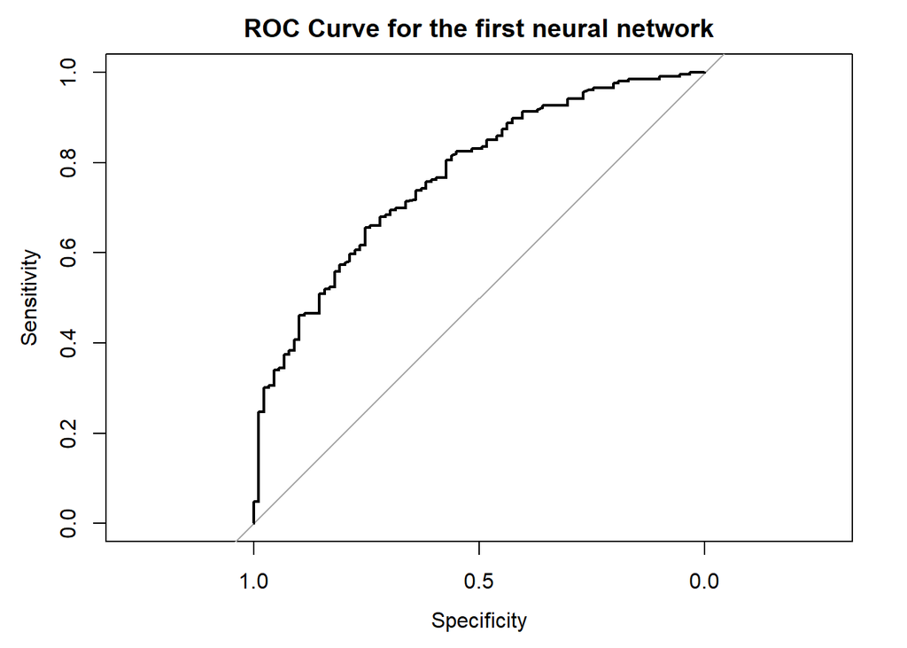

```r
# Plot the ROC curve
plot(roc_obj, main="ROC Curve for the first neural network")
```

```r
cat("AUC First Neural Network:", auc(roc_obj), "\n")
```

```
## AUC First Neural Network: 0.769772
```

```r
varImp(nn_model)
```

```
## nnet variable importance
##
##               Overall
## OWN_RES        100.00
## NEW_CAR         95.75
## USED_CAR        54.60
## HISTORY         50.39
## OTHER_INSTALL   50.16
## CHK_ACCT        46.18
## SAV_ACCT        19.32
## INSTALL_RATE    12.63
## DURATION         0.00
```

As we can see, the accuracy of the model is mediocre at best. With `0.71`, and a sensitivity of `0.63`, the model is essentially tossing a coin-flip for every bad client. Furthermore, we can see that Caret chose bootstrapping instead of cross-validation, so let’s try it in the next model:

```r
source_url('https://gist.githubusercontent.com/fawda123/7471137/raw/466c1474d0a505ff044412703516c34f1a4684a5/nnet_plot_update.r')
```

```
## ℹ SHA-1 hash of file is "74c80bd5ddbc17ab3ae5ece9c0ed9beb612e87ef"
```

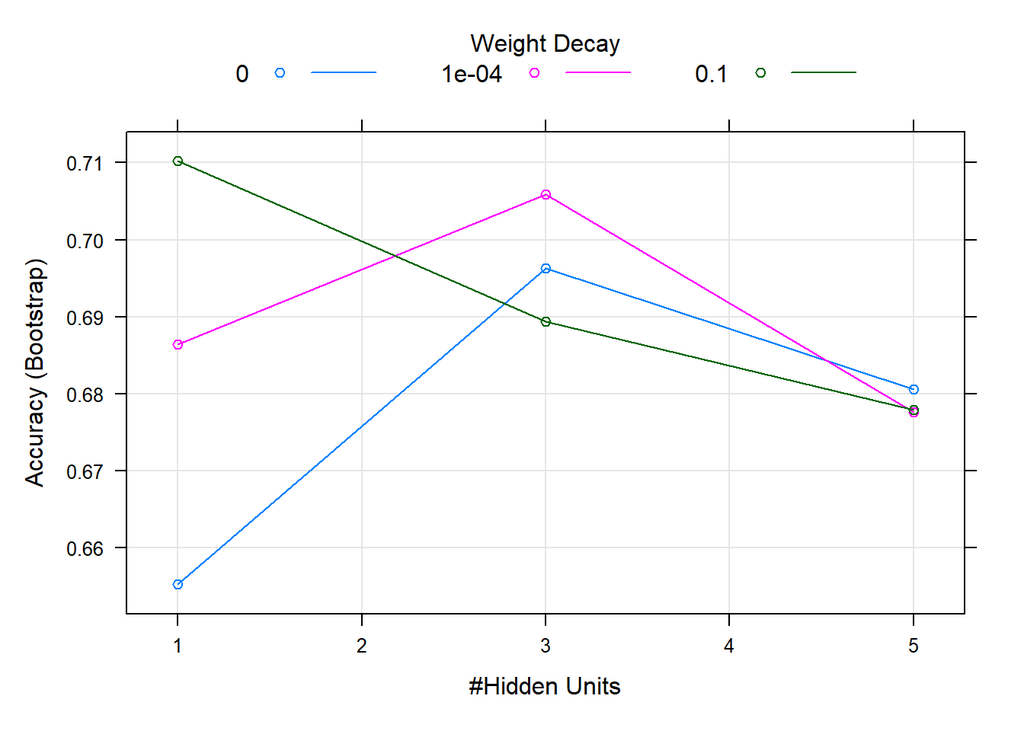

```r
plot(nn_model)
```

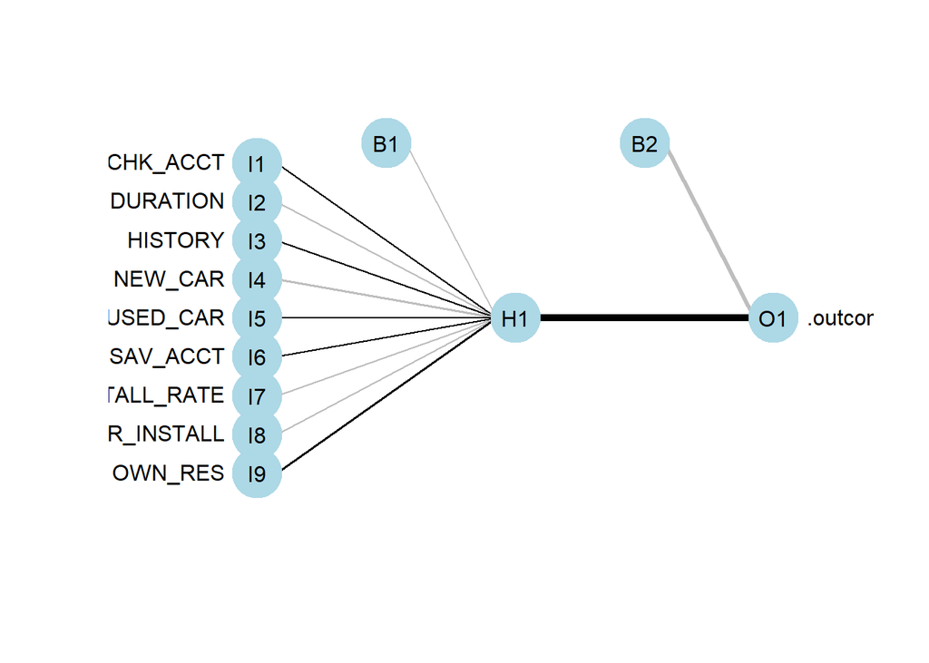

```r
plot.nnet(nn_model)
```

```r
# Train the 2st NN
 set.seed(42)

ctrl <- trainControl(method = "repeatedcv",
                     sampling = "down",
                     savePredictions = "final")
nn_model <- train(RESPONSE ~ .,
                  data = train_data,
                  method = "nnet",
                  trControl = ctrl,
                  linout = FALSE,
                  trace = FALSE,
                  metric = "Accuracy")

# Print the model
print(nn_model)
```

```
## Neural Network
##
## 687 samples
##   9 predictor
##   2 classes: 'Bad', 'Good'
##
## No pre-processing
## Resampling: Cross-Validated (10 fold, repeated 1 times)
## Summary of sample sizes: 619, 618, 619, 618, 618, 618, ...
## Addtional sampling using down-sampling
##
## Resampling results across tuning parameters:
##
##   size  decay  Accuracy   Kappa
##   1     0e+00  0.6870205  0.3160320
##   1     1e-04  0.6015132  0.2493130
##   1     1e-01  0.7292626  0.4111203
##   3     0e+00  0.6652387  0.3240193
##   3     1e-04  0.6957587  0.3395588
##   3     1e-01  0.6900469  0.3318223
##   5     0e+00  0.6885976  0.3267064
##   5     1e-04  0.7002131  0.3427681
##   5     1e-01  0.6840793  0.3247881
##
## Accuracy was used to select the optimal model using the largest value.
## The final values used for the model were size = 1 and decay = 0.1.
```

```r
# Make predictions on the test dataset
predictions_nn <- predict(nn_model, test_data)

# Evaluate the model using a confusion matrix
cm_nn <- confusionMatrix(predictions_nn, test_data$RESPONSE)
print(cm_nn)
```

```
## Confusion Matrix and Statistics
##
##           Reference
## Prediction Bad Good
##       Bad   57   56
##       Good  32  150
##
##                Accuracy : 0.7017
##                  95% CI : (0.6459, 0.7533)
##     No Information Rate : 0.6983
##     P-Value [Acc > NIR] : 0.47806
##
##                   Kappa : 0.3424
##
##  Mcnemar's Test P-Value : 0.01421
##
##             Sensitivity : 0.6404
##             Specificity : 0.7282
##          Pos Pred Value : 0.5044
##          Neg Pred Value : 0.8242
##              Prevalence : 0.3017
##          Detection Rate : 0.1932
##    Detection Prevalence : 0.3831
##       Balanced Accuracy : 0.6843
##
##        'Positive' Class : Bad
##
```

```r
predicted_probs <- predict(nn_model, newdata = test_data, type = "prob")[,2]
roc_obj <- roc(test_data$RESPONSE, predicted_probs)
```

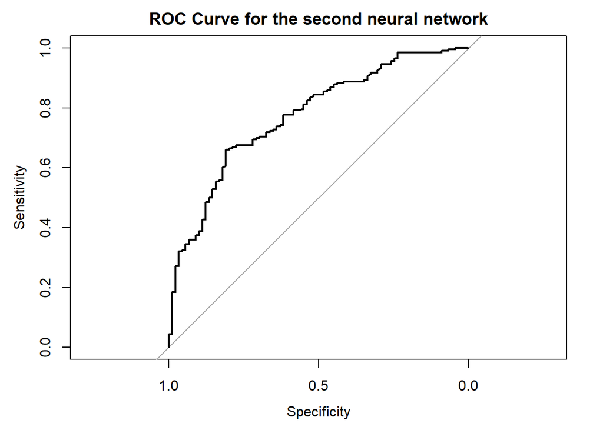

```r
# Plot the ROC curve
plot(roc_obj, main="ROC Curve for the second neural network")
```

```r
cat("AUC Second Neural Network:", auc(roc_obj), "\n")
```

```
## AUC Second Neural Network: 0.7734264
```

```r
varImp(nn_model)
```

```
## nnet variable importance
##
##               Overall
## USED_CAR      100.000
## NEW_CAR        88.331
## OWN_RES        72.674
## CHK_ACCT       49.164
## HISTORY        40.085
## OTHER_INSTALL  31.172
## SAV_ACCT       26.820
## INSTALL_RATE    9.041
## DURATION        0.000
```

```r
source_url('https://gist.githubusercontent.com/fawda123/7471137/raw/466c1474d0a505ff044412703516c34f1a4684a5/nnet_plot_update.r')
```

```
## ℹ SHA-1 hash of file is "74c80bd5ddbc17ab3ae5ece9c0ed9beb612e87ef"
```

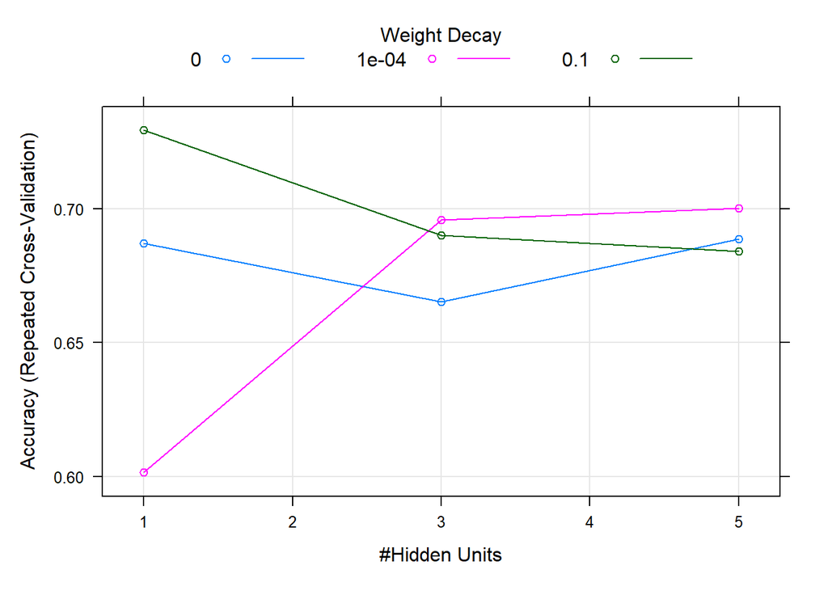

```r
plot(nn_model)
```

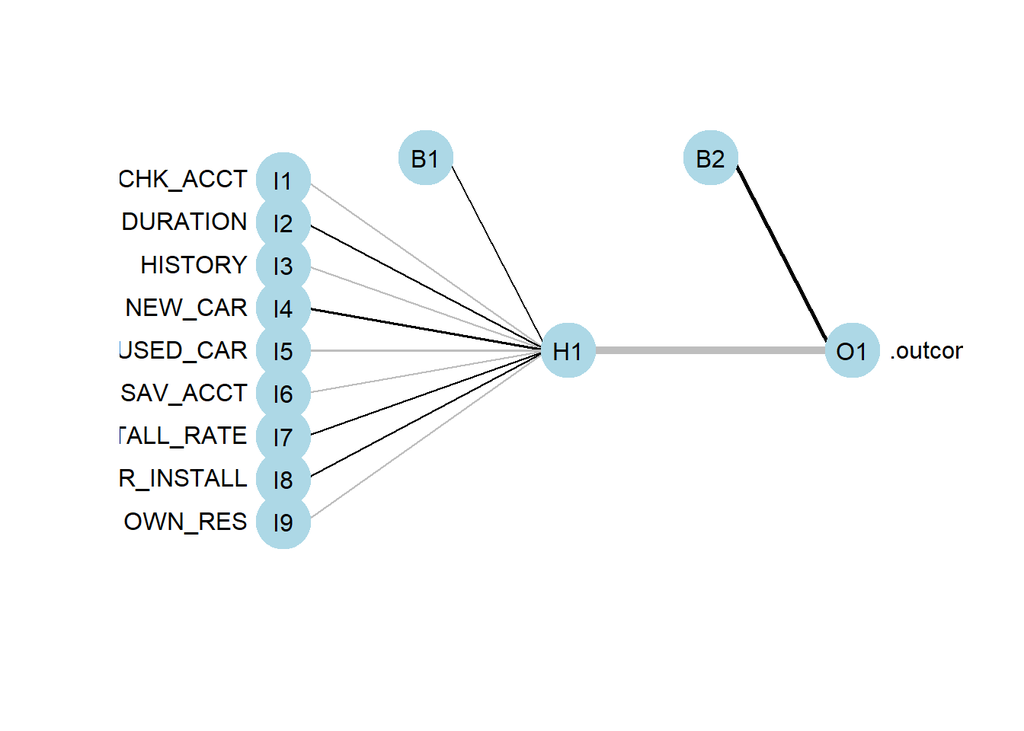

```r
plot.nnet(nn_model)
```

Better overall accuracy and sensitivity, so let’s see the difference with manually adjusted parameters:

```r
# Train the 3rd NN
set.seed(42)

 #set.seed(42)
ctrl <- trainControl(method = "repeatedcv",
                          sampling = "down",
                          savePredictions = "final")

size<-c(1,2,3,4,5,6,7,8,9,10)
decay<-c(1e-1,1e-2,1e-3,1e-4,1e-5,1e0,1e1,1e2,1e3)

tunegrid_nnet <- expand.grid(size=size,
                             decay=decay)

nn_model <- train(RESPONSE ~ .,
                  data = train_data,
                  method = "nnet",
                  trControl = ctrl,
                  linout = FALSE,
                  trace = FALSE,
                  tuneGrid = tunegrid_nnet,
                  metric="Accuracy")

# Print the model
print(nn_model)
```

```
## Neural Network
##
## 687 samples
##   9 predictor
##   2 classes: 'Bad', 'Good'
##
## No pre-processing
## Resampling: Cross-Validated (10 fold, repeated 1 times)
## Summary of sample sizes: 619, 618, 619, 618, 618, 618, ...
## Addtional sampling using down-sampling
##
## Resampling results across tuning parameters:
##
##   size  decay  Accuracy   Kappa
##    1    1e-05  0.7073316  0.36275430
```

[output cut: 92 more lines]

```r
# Make predictions on the test dataset
predictions_nn <- predict(nn_model, test_data)

# Evaluate the model using a confusion matrix
cm_nn <- confusionMatrix(predictions_nn, test_data$RESPONSE)
print(cm_nn)
```

```
## Confusion Matrix and Statistics
##
##           Reference
## Prediction Bad Good
##       Bad   59   55
##       Good  30  151
##
##                Accuracy : 0.7119
##                  95% CI : (0.6565, 0.7629)
##     No Information Rate : 0.6983
##     P-Value [Acc > NIR] : 0.331019
##
##                   Kappa : 0.3667
##
##  Mcnemar's Test P-Value : 0.009237
##
##             Sensitivity : 0.6629
##             Specificity : 0.7330
##          Pos Pred Value : 0.5175
##          Neg Pred Value : 0.8343
##              Prevalence : 0.3017
##          Detection Rate : 0.2000
##    Detection Prevalence : 0.3864
##       Balanced Accuracy : 0.6980
##
##        'Positive' Class : Bad
##
```

```r
predicted_probs <- predict(nn_model, newdata = test_data, type = "prob")[,2]
roc_obj <- roc(test_data$RESPONSE, predicted_probs)
```

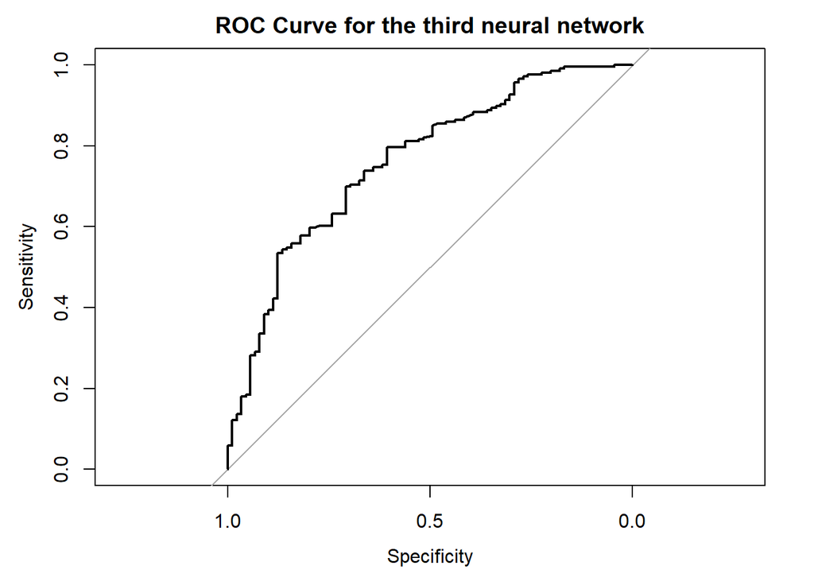

```r
# Plot the ROC curve
plot(roc_obj, main="ROC Curve for the third neural network")
```

```r
varImp(nn_model)
```

```
## nnet variable importance
##
##               Overall
## OWN_RES        100.00
## OTHER_INSTALL   67.34
## CHK_ACCT        55.68
## HISTORY         49.70
## USED_CAR        33.43
## SAV_ACCT        32.25
## NEW_CAR         27.93
## INSTALL_RATE    24.61
## DURATION         0.00
```

```r
cat("AUC Neural Network final:", auc(roc_obj), "\n")
```

```
## AUC Neural Network final: 0.7608814
```

```r
source_url('https://gist.githubusercontent.com/fawda123/7471137/raw/466c1474d0a505ff044412703516c34f1a4684a5/nnet_plot_update.r')
```

```
## ℹ SHA-1 hash of file is "74c80bd5ddbc17ab3ae5ece9c0ed9beb612e87ef"
```

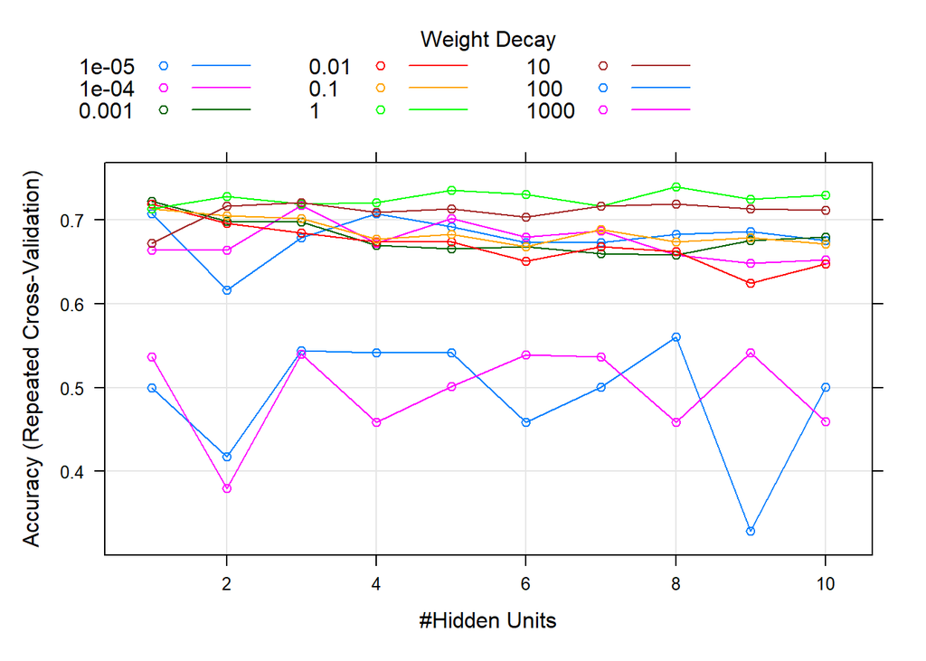

```r
plot(nn_model)
```

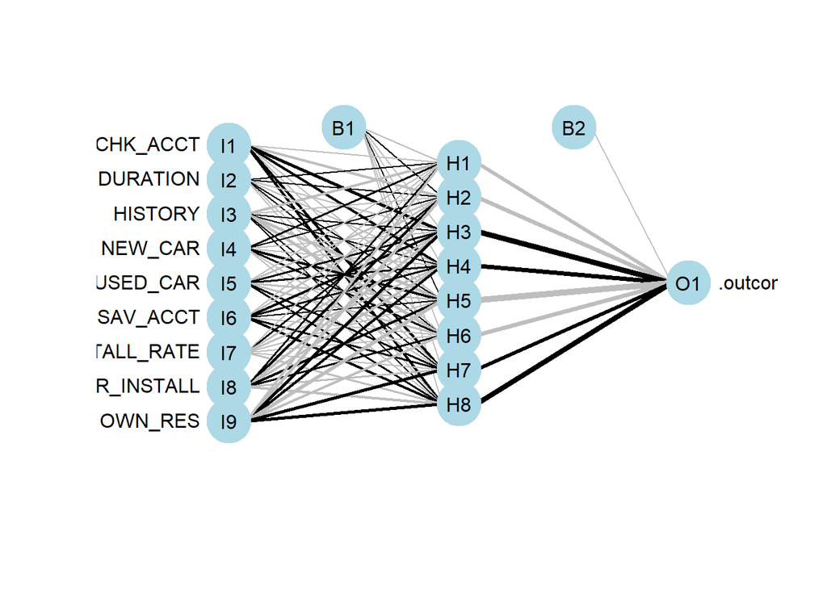

```r
plot.nnet(nn_model)
```

From the 3 models, the last one also shows a Kappa slightly higher than the other ones but the difference is not significant in our eyes. The lack of further improvement may be caused of the lack of further predictor variables. It is known that Neural Networks love predictors because they can adjust their weights with more precision.

We could be creating another model with more hidden layers, but the difference will not be significant.

## Support vector (SVM)

Linear model:

```r
set.seed(42)

svm_model_lin <- train(RESPONSE ~ .,
                   data = train_data,
                   method = "svmLinear",
                   trControl = ctrl,
                   epochs = 100,
                   tuneLength = 100,
                   verbose = FALSE)

# Print the model
print(svm_model_lin)
```

```
## Support Vector Machines with Linear Kernel
##
## 687 samples
##   9 predictor
##   2 classes: 'Bad', 'Good'
##
## No pre-processing
## Resampling: Cross-Validated (10 fold, repeated 1 times)
## Summary of sample sizes: 619, 618, 619, 618, 618, 618, ...
## Addtional sampling using down-sampling
##
## Resampling results:
##
##   Accuracy   Kappa
##   0.7219949  0.4032894
##
## Tuning parameter 'C' was held constant at a value of 1
```

```r
# Make predictions on the test dataset
predictions_svm_lin <- predict(svm_model_lin, test_data)

# Evaluate the model using a confusion matrix
cm_svm_lin <- confusionMatrix(predictions_svm_lin, test_data$RESPONSE)
print(cm_svm_lin)
```

```
## Confusion Matrix and Statistics
##
##           Reference
## Prediction Bad Good
##       Bad   60   61
##       Good  29  145
##
##                Accuracy : 0.6949
##                  95% CI : (0.6389, 0.747)
##     No Information Rate : 0.6983
##     P-Value [Acc > NIR] : 0.578596
##
##                   Kappa : 0.343
##
##  Mcnemar's Test P-Value : 0.001084
##
##             Sensitivity : 0.6742
##             Specificity : 0.7039
##          Pos Pred Value : 0.4959
##          Neg Pred Value : 0.8333
##              Prevalence : 0.3017
##          Detection Rate : 0.2034
##    Detection Prevalence : 0.4102
##       Balanced Accuracy : 0.6890
##
##        'Positive' Class : Bad
##
```

```r
varImp(svm_model_lin)
```

```
## ROC curve variable importance
##
##               Importance
## CHK_ACCT         100.000
## DURATION          70.016
## HISTORY           53.085
## SAV_ACCT          46.557
## OWN_RES           46.108
## OTHER_INSTALL     11.667
## INSTALL_RATE       8.914
## NEW_CAR            5.069
## USED_CAR           0.000
```

Let’s try the Radial model:

```r
set.seed(42)

C<-c(0.1, 1, 10, 100)
sigma<-c(0.0001, 0.001, 0.01, 0.1, 1)
gr.radial<-expand.grid(C=C, sigma=sigma)

svm_model_radial <- train(RESPONSE ~ .,
                   data = train_data,
                   method = "svmRadial",
                   trControl = ctrl,
                   tuneGrid = gr.radial,
                   verbose = FALSE)

# Print the model
print(svm_model_radial)
```

```
## Support Vector Machines with Radial Basis Function Kernel
##
## 687 samples
##   9 predictor
##   2 classes: 'Bad', 'Good'
##
## No pre-processing
## Resampling: Cross-Validated (10 fold, repeated 1 times)
## Summary of sample sizes: 619, 618, 619, 618, 618, 618, ...
## Addtional sampling using down-sampling
##
## Resampling results across tuning parameters:
##
##   C      sigma  Accuracy   Kappa
##     0.1  1e-04  0.6986360  0.3706764
##     0.1  1e-03  0.7118500  0.3898694
##     0.1  1e-02  0.7205243  0.4030647
##     0.1  1e-01  0.7015132  0.3683763
##     0.1  1e+00  0.5170929  0.1586565
##     1.0  1e-04  0.6913683  0.3592928
##     1.0  1e-03  0.7175618  0.3893773
##     1.0  1e-02  0.7074169  0.3782929
##     1.0  1e-01  0.7028986  0.3506313
##     1.0  1e+00  0.6142157  0.2208353
##    10.0  1e-04  0.7292199  0.4177250
##    10.0  1e-03  0.7147272  0.3928715
##    10.0  1e-02  0.7261083  0.4092807
##    10.0  1e-01  0.6665814  0.2845823
##    10.0  1e+00  0.6082907  0.2230804
##   100.0  1e-04  0.7031330  0.3764641
##   100.0  1e-03  0.7161552  0.3946917
##   100.0  1e-02  0.7044118  0.3616870
##   100.0  1e-01  0.6359335  0.2208643
##   100.0  1e+00  0.6069267  0.2006081
##
## Accuracy was used to select the optimal model using the largest value.
## The final values used for the model were sigma = 1e-04 and C = 10.
```

```r
# Make predictions on the test dataset
predictions_svm_radial <- predict(svm_model_radial, test_data)

# Evaluate the model using a confusion matrix
cm_svm_radial <- confusionMatrix(predictions_svm_radial, test_data$RESPONSE)
print(cm_svm_radial)
```

```
## Confusion Matrix and Statistics
##
##           Reference
## Prediction Bad Good
##       Bad   62   61
##       Good  27  145
##
##                Accuracy : 0.7017
##                  95% CI : (0.6459, 0.7533)
##     No Information Rate : 0.6983
##     P-Value [Acc > NIR] : 0.4780553
##
##                   Kappa : 0.3613
##
##  Mcnemar's Test P-Value : 0.0004351
##
##             Sensitivity : 0.6966
##             Specificity : 0.7039
##          Pos Pred Value : 0.5041
##          Neg Pred Value : 0.8430
##              Prevalence : 0.3017
##          Detection Rate : 0.2102
##    Detection Prevalence : 0.4169
##       Balanced Accuracy : 0.7003
##
##        'Positive' Class : Bad
##
```

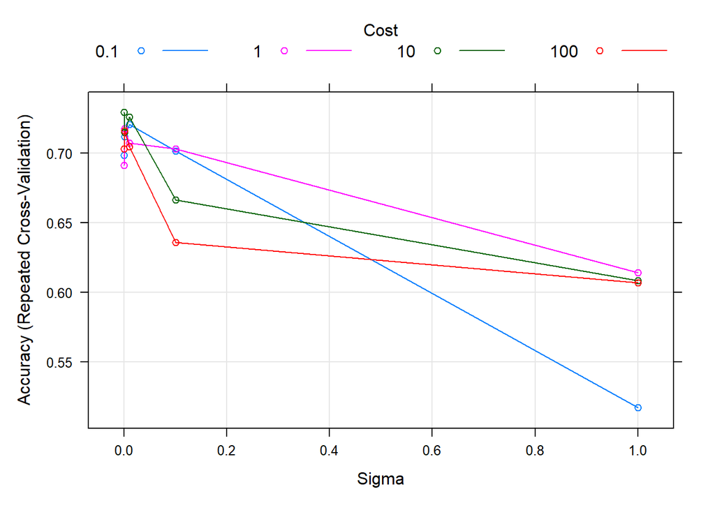

```r
plot(svm_model_radial)
```

```r
varImp(svm_model_radial)
```

```
## ROC curve variable importance
##
##               Importance
## CHK_ACCT         100.000
## DURATION          70.016
## HISTORY           53.085
## SAV_ACCT          46.557
## OWN_RES           46.108
## OTHER_INSTALL     11.667
## INSTALL_RATE       8.914
## NEW_CAR            5.069
## USED_CAR           0.000
```

Now let’s try the polynomial kernel basis:

```r
set.seed(42)

C<-c(0.1, 1, 10, 100)
degree<-c(1, 2, 3)
scale<-1
gr.poly<-expand.grid(C=C, degree=degree, scale=scale)

svm_model_poly <- train(RESPONSE ~ .,
                   data = train_data,
                   method = "svmPoly",
                   trControl = ctrl,
                   verbose = FALSE,
                   tuneGrid = gr.poly)

# Print the model
print(svm_model_poly)
```

```
## Support Vector Machines with Polynomial Kernel
##
## 687 samples
##   9 predictor
##   2 classes: 'Bad', 'Good'
##
## No pre-processing
## Resampling: Cross-Validated (10 fold, repeated 1 times)
## Summary of sample sizes: 619, 618, 619, 618, 618, 618, ...
## Addtional sampling using down-sampling
##
## Resampling results across tuning parameters:
##
##   C      degree  Accuracy   Kappa
##     0.1  1       0.7175831  0.3956274
##     0.1  2       0.7058397  0.3606899
##     0.1  3       0.6244032  0.2056195
##     1.0  1       0.7117008  0.3716279
##     1.0  2       0.6767903  0.3012266
##     1.0  3       0.5967391  0.1515524
##    10.0  1       0.7029625  0.3684547
##    10.0  2       0.6927110  0.3405843
##    10.0  3       0.5938406  0.1636232
##   100.0  1       0.7247869  0.4072452
##   100.0  2       0.6926471  0.3309171
##   100.0  3       0.5706735  0.1205377
##
## Tuning parameter 'scale' was held constant at a value of 1
## Accuracy was used to select the optimal model using the largest value.
## The final values used for the model were degree = 1, scale = 1 and C = 100.
```

```r
# Make predictions on the test dataset
predictions_svm_poly <- predict(svm_model_poly, test_data)

# Evaluate the model using a confusion matrix
cm_svm_poly <- confusionMatrix(predictions_svm_poly, test_data$RESPONSE)
print(cm_svm_poly)
```

```
## Confusion Matrix and Statistics
##
##           Reference
## Prediction Bad Good
##       Bad   61   65
##       Good  28  141
##
##                Accuracy : 0.6847
##                  95% CI : (0.6284, 0.7374)
##     No Information Rate : 0.6983
##     P-Value [Acc > NIR] : 0.7178160
##
##                   Kappa : 0.3308
##
##  Mcnemar's Test P-Value : 0.0001892
##
##             Sensitivity : 0.6854
##             Specificity : 0.6845
##          Pos Pred Value : 0.4841
##          Neg Pred Value : 0.8343
##              Prevalence : 0.3017
##          Detection Rate : 0.2068
##    Detection Prevalence : 0.4271
##       Balanced Accuracy : 0.6849
##
##        'Positive' Class : Bad
##
```

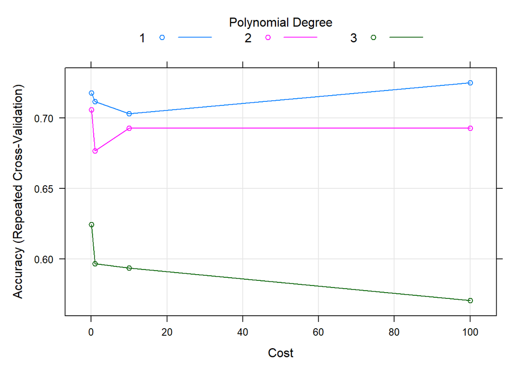

```r
plot(svm_model_poly)
```

```r
varImp(svm_model_poly)
```

```
## ROC curve variable importance
##
##               Importance
## CHK_ACCT         100.000
## DURATION          70.016
## HISTORY           53.085
## SAV_ACCT          46.557
## OWN_RES           46.108
## OTHER_INSTALL     11.667
## INSTALL_RATE       8.914
## NEW_CAR            5.069
## USED_CAR           0.000
```

Comparing prediction accuracies (resampling the models):

```r
set.seed(42)

models<-list(lin = svm_model_lin, poly=svm_model_poly, radial=svm_model_radial) # create a list of models
resample_results <- resamples(models) # resample the models
summary(resample_results, metric=c("Kappa", "Accuracy")) # generate a summary
```

```
##
## Call:
## summary.resamples(object = resample_results, metric = c("Kappa", "Accuracy"))
##
## Models: lin, poly, radial
## Number of resamples: 10
##
## Kappa
##             Min.   1st Qu.    Median      Mean   3rd Qu.      Max. NA's
## lin    0.2755906 0.3327836 0.3810981 0.4032894 0.4806188 0.5440613    0
## poly   0.2580645 0.3924940 0.4174543 0.4072452 0.4534068 0.5208333    0
## radial 0.2974768 0.3913614 0.4124056 0.4177250 0.4485656 0.5892857    0
##
## Accuracy
##             Min.   1st Qu.    Median      Mean   3rd Qu.      Max. NA's
## lin    0.6521739 0.6836637 0.7079071 0.7219949 0.7767477 0.7971014    0
## poly   0.6521739 0.7205882 0.7391304 0.7247869 0.7391304 0.7971014    0
## radial 0.6666667 0.7216006 0.7246377 0.7292199 0.7355072 0.8260870    0
```

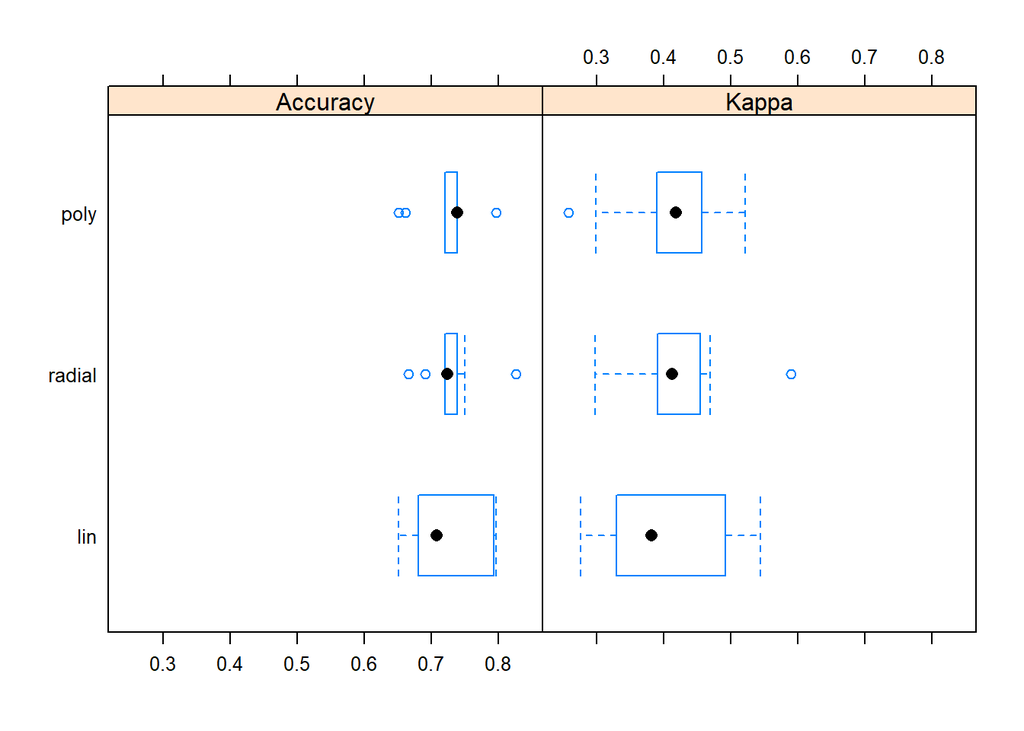

```r
bwplot(resample_results , metric=c("Kappa","Accuracy")) # create a boxplot
```

As we can see from these results, the Polynomial and Radial SVMs are quite similar accuracy-wise, making the Linear model fall behind with a bigger boxplot. This may be caused because the Linear model does not fit the data well because of the lack of possible curvature. On the other hand, looking at the Kappas, the whiskers of the Polynomial are larger than the Radial. The latter also has a Extreme Value at around `0.59`, but the overall Kappa is less high than than the Polynomial. Based on these factors, we would will declare the `Radial` model as the best here.

## Gradient Boosting

### GBM

```r
set.seed(42)

gbm_model <- train(RESPONSE ~ .,
                   data = train_data,
                   method = "gbm",
                   trControl = ctrl,
                   verbose = FALSE)

# Print the model
print(gbm_model)
```

```
## Stochastic Gradient Boosting
##
## 687 samples
##   9 predictor
##   2 classes: 'Bad', 'Good'
##
## No pre-processing
## Resampling: Cross-Validated (10 fold, repeated 1 times)
## Summary of sample sizes: 619, 618, 619, 618, 618, 618, ...
## Addtional sampling using down-sampling
##
## Resampling results across tuning parameters:
##
##   interaction.depth  n.trees  Accuracy   Kappa
##   1                   50      0.6754689  0.3281070
##   1                  100      0.6957587  0.3539532
##   1                  150      0.7001279  0.3626457
##   2                   50      0.7073956  0.3740027
##   2                  100      0.7029838  0.3611661
##   2                  150      0.6928389  0.3420831
##   3                   50      0.7117647  0.3802035
##   3                  100      0.7145354  0.3943663
##   3                  150      0.6942882  0.3529764
##
## Tuning parameter 'shrinkage' was held constant at a value of 0.1
##
## Tuning parameter 'n.minobsinnode' was held constant at a value of 10
## Accuracy was used to select the optimal model using the largest value.
## The final values used for the model were n.trees = 100, interaction.depth =
##  3, shrinkage = 0.1 and n.minobsinnode = 10.
```

```r
# Make predictions on the test dataset
predictions_gbm <- predict(gbm_model, test_data)


# Evaluate the model using a confusion matrix
cm_gbm <- confusionMatrix(predictions_gbm, test_data$RESPONSE)
print(cm_gbm)
```

```
## Confusion Matrix and Statistics
##
##           Reference
## Prediction Bad Good
##       Bad   60   65
##       Good  29  141
##
##                Accuracy : 0.6814
##                  95% CI : (0.6249, 0.7342)
##     No Information Rate : 0.6983
##     P-Value [Acc > NIR] : 0.7586257
##
##                   Kappa : 0.3217
##
##  Mcnemar's Test P-Value : 0.0003062
##
##             Sensitivity : 0.6742
##             Specificity : 0.6845
##          Pos Pred Value : 0.4800
##          Neg Pred Value : 0.8294
##              Prevalence : 0.3017
##          Detection Rate : 0.2034
##    Detection Prevalence : 0.4237
##       Balanced Accuracy : 0.6793
##
##        'Positive' Class : Bad
##
```

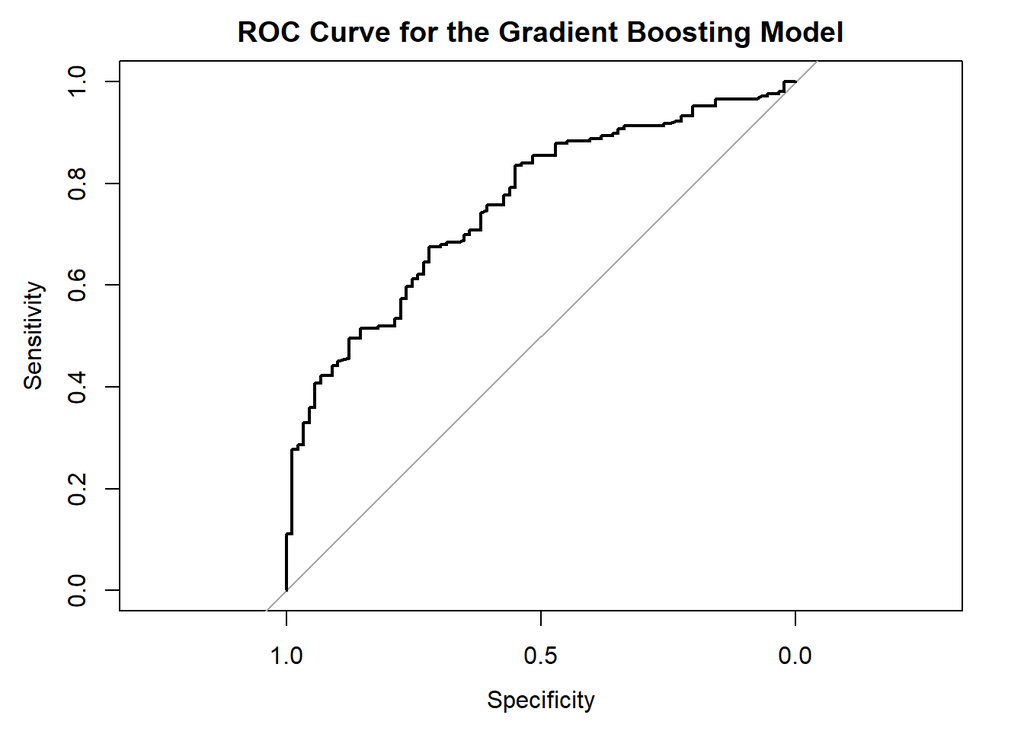

```r
predicted_probs_gbm <- predict(gbm_model, newdata = test_data, type = "prob")[,2]

# Create the ROC curve
roc_obj_gbm <- roc(test_data$RESPONSE, predicted_probs_gbm)
# Plot the ROC curve
plot(roc_obj_gbm, main="ROC Curve for the Gradient Boosting Model")
```

```r
varImp(gbm_model)
```

```
## gbm variable importance
##
##               Overall
## DURATION      100.000
## CHK_ACCT       81.969
## HISTORY        48.965
## OWN_RES        28.418
## SAV_ACCT       24.445
## OTHER_INSTALL  21.647
## INSTALL_RATE   15.192
## NEW_CAR         5.983
## USED_CAR        0.000
```

### Extreme Gradiant Boosting (XGBoost)

This model is the `surprise model` we got. Here is the model with default parameters:

```r
set.seed(42)

grid_default <- expand.grid(
  nrounds = 100,
  max_depth = 6,
  eta = 0.3,
  gamma = 0,
  colsample_bytree = 1,
  min_child_weight = 1,
  subsample = 1
)

xgb_model <- train(RESPONSE ~ .,
                   data = train_data,
                   method = "xgbTree",
                   trControl = ctrl,
                   tuneGrid = grid_default,
                   verbose = FALSE)

# Print the model
print(xgb_model)
```

```
## eXtreme Gradient Boosting
##
## 687 samples
##   9 predictor
##   2 classes: 'Bad', 'Good'
##
## No pre-processing
## Resampling: Cross-Validated (10 fold, repeated 1 times)
## Summary of sample sizes: 619, 618, 619, 618, 618, 618, ...
## Addtional sampling using down-sampling
##
## Resampling results:
##
##   Accuracy   Kappa
##   0.6403666  0.2569497
##
## Tuning parameter 'nrounds' was held constant at a value of 100
## Tuning
##  held constant at a value of 1
## Tuning parameter 'subsample' was held
##  constant at a value of 1
```

```r
# Make predictions on the test dataset
predictions_xgb <- predict(xgb_model, test_data)

# Evaluate the model using a confusion matrix
cm_xgb <- confusionMatrix(predictions_xgb, test_data$RESPONSE)
print(cm_xgb)
```

```
## Confusion Matrix and Statistics
##
##           Reference
## Prediction Bad Good
##       Bad   56   84
##       Good  33  122
##
##                Accuracy : 0.6034
##                  95% CI : (0.5451, 0.6596)
##     No Information Rate : 0.6983
##     P-Value [Acc > NIR] : 0.9998
##
##                   Kappa : 0.1905
##
##  Mcnemar's Test P-Value : 3.791e-06
##
##             Sensitivity : 0.6292
##             Specificity : 0.5922
##          Pos Pred Value : 0.4000
##          Neg Pred Value : 0.7871
##              Prevalence : 0.3017
##          Detection Rate : 0.1898
##    Detection Prevalence : 0.4746
##       Balanced Accuracy : 0.6107
##
##        'Positive' Class : Bad
##
```

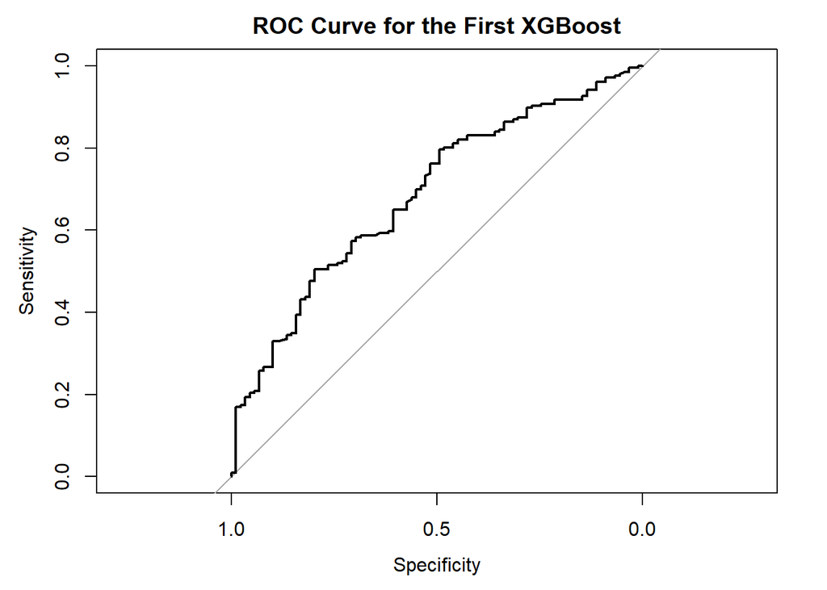

```r
predicted_probs <- predict(xgb_model, newdata = test_data, type = "prob")[,2]

# Create the ROC curve
roc_obj <- roc(test_data$RESPONSE, predicted_probs)
# Plot the ROC curve
plot(roc_obj, main="ROC Curve for the First XGBoost")
```

```r
varImp(xgb_model)
```

```
## xgbTree variable importance
##
##               Overall
## DURATION      100.000
## CHK_ACCT       87.149
## SAV_ACCT       44.619
## HISTORY        37.324
## INSTALL_RATE   36.701
## OWN_RES        26.704
## OTHER_INSTALL  11.681
## NEW_CAR         4.684
## USED_CAR        0.000
```

```r
set.seed(42)
nrounds <-  seq(from = 100, to = 1000, by = 100)
tune_grid <- expand.grid(
  nrounds = nrounds,
  eta = c(0.125, 0.025, 0.05, 0.1, 0.3),
  max_depth = c(2, 3, 4, 5, 6, 7),
  gamma = 0,
  colsample_bytree = 1,
  min_child_weight = 1,
  subsample = 1
)

xgb_model <- train(RESPONSE ~ .,
                   data = train_data,
                   method = "xgbTree",
                   trControl = ctrl,
                   tuneGrid = tune_grid,
                   verbose = FALSE)

# Print the model
print(xgb_model)
```

```
## eXtreme Gradient Boosting
##
## 687 samples
##   9 predictor
##   2 classes: 'Bad', 'Good'
##
## No pre-processing
## Resampling: Cross-Validated (10 fold, repeated 1 times)
## Summary of sample sizes: 619, 618, 619, 618, 618, 618, ...
## Addtional sampling using down-sampling
##
## Resampling results across tuning parameters:
##
##   eta    max_depth  nrounds  Accuracy   Kappa
##   0.025  2           100     0.7000426  0.3657764
##   0.025  2           200     0.7058397  0.3728296
##   0.025  2           300     0.7028772  0.3722019
##   0.025  2           400     0.6970801  0.3614028
##   0.025  2           500     0.7029199  0.3752807
##   0.025  2           600     0.7000000  0.3680802
##   0.025  2           700     0.6956309  0.3609388
##   0.025  2           800     0.6956522  0.3624286
##   0.025  2           900     0.6912830  0.3508529
##   0.025  2          1000     0.6869139  0.3410777
##   0.025  3           100     0.6856138  0.3411909
##   0.025  3           200     0.6796675  0.3306065
##   0.025  3           300     0.6767263  0.3198315
##   0.025  3           400     0.6680733  0.3013491
##   0.025  3           500     0.6666027  0.3015948
##   0.025  3           600     0.6593137  0.2904794
##   0.025  3           700     0.6578431  0.2863367
##   0.025  3           800     0.6491475  0.2715672
##   0.025  3           900     0.6563939  0.2821333
##   0.025  3          1000     0.6593137  0.2883269
##   0.025  4           100     0.6797101  0.3235991
##   0.025  4           200     0.6767050  0.3108856
##   0.025  4           300     0.6825234  0.3236761
##   0.025  4           400     0.6796036  0.3172242
##   0.025  4           500     0.6781756  0.3189644
##   0.025  4           600     0.6738278  0.3100590
```

[output cut: 270 more lines]

```
##   0.300  7           700     0.6011509  0.1880015
##   0.300  7           800     0.6054987  0.1945334
##   0.300  7           900     0.6040281  0.1925658
##   0.300  7          1000     0.6069693  0.1965011
##
## Tuning parameter 'gamma' was held constant at a value of 0
## Tuning
##
## Tuning parameter 'min_child_weight' was held constant at a value of 1
##
## Tuning parameter 'subsample' was held constant at a value of 1
## Accuracy was used to select the optimal model using the largest value.
## The final values used for the model were nrounds = 200, max_depth = 2, eta
##  = 0.025, gamma = 0, colsample_bytree = 1, min_child_weight = 1 and subsample
##  = 1.
```

```r
# Make predictions on the test dataset
predictions_xgb <- predict(xgb_model, test_data)

# Evaluate the model using a confusion matrix
cm_xgb <- confusionMatrix(predictions_xgb, test_data$RESPONSE)
print(cm_xgb)
```

```
## Confusion Matrix and Statistics
##
##           Reference
## Prediction Bad Good
##       Bad   62   59
##       Good  27  147
##
##                Accuracy : 0.7085
##                  95% CI : (0.653, 0.7597)
##     No Information Rate : 0.6983
##     P-Value [Acc > NIR] : 0.3784845
##
##                   Kappa : 0.3722
##
##  Mcnemar's Test P-Value : 0.0008293
##
##             Sensitivity : 0.6966
##             Specificity : 0.7136
##          Pos Pred Value : 0.5124
##          Neg Pred Value : 0.8448
##              Prevalence : 0.3017
##          Detection Rate : 0.2102
##    Detection Prevalence : 0.4102
##       Balanced Accuracy : 0.7051
##
##        'Positive' Class : Bad
##
```

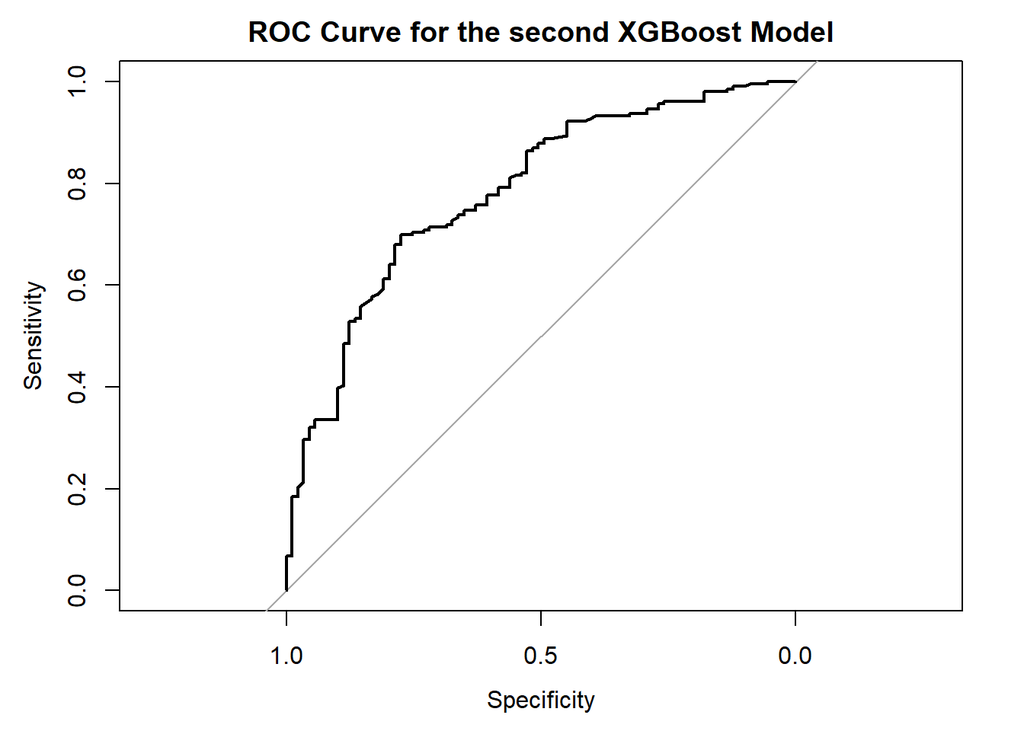

```r
predicted_probs_xgboost <- predict(xgb_model, newdata = test_data, type = "prob")[,2]

# Create the ROC curve
roc_obj_xgboost <- roc(test_data$RESPONSE, predicted_probs_xgboost)

# Plot the ROC curve
plot(roc_obj_xgboost, main="ROC Curve for the second XGBoost Model")
```

```r
varImp(xgb_model)
```

```
## xgbTree variable importance
##
##               Overall
## CHK_ACCT      100.000
## DURATION       51.482
## HISTORY        24.852
## USED_CAR       23.765
## OWN_RES        14.338
## OTHER_INSTALL  13.715
## SAV_ACCT       13.543
## INSTALL_RATE    8.351
## NEW_CAR         0.000
```

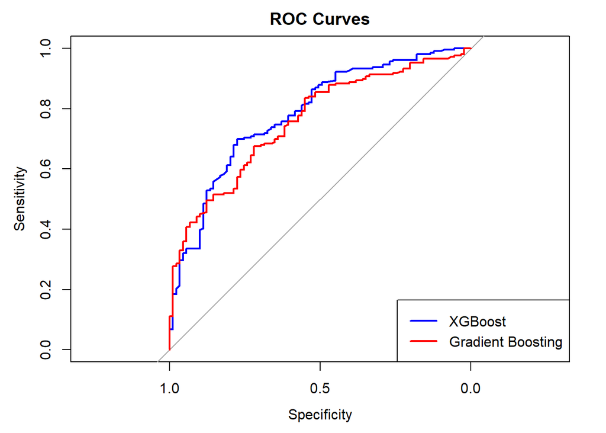

```r
# Plot ROC curves
plot.roc(roc_obj_xgboost, main="ROC Curves", percent=TRUE, col="blue")
lines.roc(roc_obj_gbm, percent=TRUE, col="red")

# Add legend
legend("bottomright", legend=c("XGBoost", "Gradient Boosting"), col=c("blue", "red"), lwd=2)
```

```r
cat("AUC XGBoost:", auc(roc_obj_xgboost), "\n")
```

```
## AUC XGBoost: 0.7828624
```

```r
cat("AUC GBM:", auc(roc_obj_gbm), "\n")
```

```
## AUC GBM: 0.7580997
```

Now, comparing the XGBoost and the ‘normal’ GBM, we can see that the XGBoost is better overall when looking at the ROC Curves. It also has a better sensitivity, which is crucial for our analysis. The overall improvement can be explained because it offers more tuning capabilities than the GBM, therefore ensuring a more substantial fit. However, was inferior in the sense that it ran approximatively 20x longer than the normal GBM, and this is a key parameter to keep in mind because our number of predictors were actually pretty low overall.

# Conclusion

After this analysis of all the models we had at our disposition, what are the main takeaways?

1. Every model shown here almost has the same Accuracy and Kappa values, which means that they behave almost the same way.
2. But if we follow the scientific approach, we would use the `Random Forest with automatic parameters` because of its highest Sensitivity combined with one of the highest accuracies of all the models.
3. Based on the above-mentioned model, the most important variables are `DURATION`, `CHK_ACCT`, and `HISTORY`. The least useful variables are the ones talking about `cars`.
4. Now that we have established the variables needed for the model, the bank clerks will need less information on the customer to make the decision to accord the credit or not.
5. In this current state, you can see that the models resemble each other a whole lot. This is important to continually train the models with fresh data to see if the fit will be better with another model.

# Limitations and further improvements

The limitations of this project are not significant, but here is a list of how we would change the methodology if we had to make the project from scratch: 1. Identify meaningful variables for each model separately, instead of choosing them deliberately at the beginning after the Logistic Regression model. This could greatly improve the models accuracy, especially for more complex models such as neural networks, SVMs, Boosting and so on.

2. The use of a more balanced dataset. Even though we used the down sampling method for each model, a more balanced dataset would have meant a more data to work with when dealing with bad clients.
3. We would make the analysis with multiple seeds and take averages for each model to see if their performance is influenced by a certain seed or not.